# INMIGRACIÓN Y DIVERSIDAD EN ESPAÑA CRISIS ECONÓMICA Y GESTIÓN MUNICIPAL

#### **Editorial:** [*ICARIA*](http://www.icariaeditorial.com/)

#### **Editor:** [*Andreu Domingo*](http://ced.uab.es/directori/andreu-domingo-valls/)

#### **Data visualization:** [*Juan Galeano*](http://ced.uab.es/directori/juan-galeano/)

Este documento contiene el código R utilizado para la confección de cada uno de los gráficos que se presentan en los distintos capítulos del libro. El unico cambio que se ha realizado a la hora de elaborar este documento han sido unos ligeros ajustes sobre el tamaño de las fuentes.

En el caso de los figuras que contienen mapas gran parte del análisis estadístico también fue realizado con R. Sin embargo, a la hora de visualizar esos resultados sobre el territorio se ha utilizado el programa QGIS. Aqui sólo aparece el mapa final, no el código de análsisi del cual emanan los resultados.

### **Capítulo 1: IMIGRACIÓN INTERNACIONAL Y CAMBIO DEMOGRÁFICO EN EL NUEVO MILENIO [Autores: Juan Galeano & Albert Sabater]**

#### **Figura 1.1: Población nacida en el extranjero según región de nacimiento por Comunidad Autónoma, 2000-2014**

```r
library (dplyr)
```

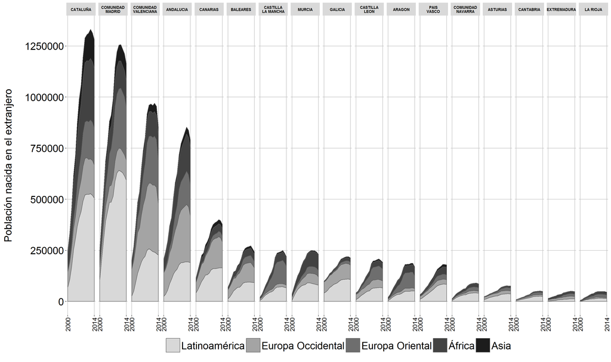

```r
library(ggplot2)

load("C:\\Users\\jgaleano\\Desktop\\ICARIA\\DATOS_ICARIA_1.Rdata")
dffinal<-dffinal[!dffinal$COM=="CEUTA Y MELILLA", ]
dffinal$COM<-with(dffinal, ifelse(COM=="CATALUNYA", "CATALUÑA", COM))


POPEXTCOM <- dffinal %>% group_by(COM,YEAR) %>%  summarise(secciones = n(),
                                                 Spanish = sum(Spanish),
                                                 LatinaAmerica = sum(LatinAmerica),
                                                 WesternEurope = sum(WesternEurope),
                                                 EasternEurope = sum(EasternEurope),
                                                 Africa = sum(Africa),
                                                 Asia = sum(Asia),
                                                 Others = sum(Others),
                                                 Total_ext=sum(Total_ext),
                                                 Totalpop=sum(Totalpop))




POPEXT <- with(POPEXTCOM, c(LatinaAmerica,WesternEurope,EasternEurope,Africa,Asia))
GRUP <-rep(c("Latinoamérica","Europa Occidental","Europa Oriental","África","Asia"), each=255)
COM <- rep(POPEXTCOM$COM, 5)
YEAR<- rep(POPEXTCOM$YEAR, 5)
POPEXT <-data.frame(GRUP,POPEXT,YEAR,COM)



POPEXT$COM <- factor(POPEXTCOM$COM,
                   levels = c( "CATALUÑA","COMUNIDAD\nMADRID","COMUNIDAD\nVALENCIANA",
                               "ANDALUCIA","CANARIAS","BALEARES","CASTILLA\nLA MANCHA",
                               "MURCIA","GALICIA","CASTILLA\nLEON", "ARAGON",
                               "PAIS\nVASCO", "COMUNIDAD\nNAVARRA","ASTURIAS","CANTABRIA",
                               "EXTREMADURA", "LA RIOJA"))

POPEXT$GRUP <- factor(POPEXT$GRUP,
                     levels = c("Latinoamérica","Europa Occidental","Europa Oriental","África","Asia"))

A <-ggplot(data=POPEXT, aes(x=YEAR, y=POPEXT, fill=GRUP)) +
  geom_area(stat="identity", colour="#585858")+
  scale_y_continuous(breaks=seq(0, 1250000, 250000))+
  scale_x_continuous(breaks=c(2000, 2014))+
  facet_wrap(~ COM, nrow=1)+
  scale_fill_manual(name="",
                     values=c("#D8D8D8", "#A4A4A4", "#6E6E6E", "#424242", "#1C1C1C"),
                     breaks=c("Latinoamérica","Europa Occidental","Europa Oriental","África","Asia"),
                     labels=c("Latinoamérica","Europa Occidental","Europa Oriental","África","Asia"))+
  theme(plot.title = element_text(lineheight=5.6, size=20, face="bold"),
              legend.title = element_blank(),
              legend.text = element_text(colour="black", size = 20),
              legend.position="bottom",
              legend.background = element_rect(fill="#FFFFFF"),
              legend.justification=c(0,1),
              legend.key.size = unit(1, "cm"),
              axis.title.x = element_blank(),
              axis.text.x  = element_text(angle = 90,vjust=0.5, size=12,colour="black"),
              axis.title.y = element_text(colour="black", size=20),
              axis.text.y  = element_text(vjust=0.5, size=20,colour="black"),
              strip.text=element_text(angle = 0,vjust=0.5, size=7.5,colour="black", face = "bold"),
              panel.background = element_rect(fill = "#FFFFFF"),
              panel.grid = element_line(colour="#000000"),
              panel.grid.major=element_line(colour="#BDBDBD"),
              panel.grid.minor=element_line(colour="white"),
              plot.background = element_rect(fill = "#FFFFFF"))+ ylab("Población nacida en el extranjero\n")
A
```

```r
setwd("C:\\Users\\jgaleano\\Desktop\\ICARIA\\GRAFICOS")
#ggsave("CAP1_FIG1_POBLACION_EXTRANJERA_POR_COMUNIDAD_2000_2014.tiff", scale = 3, width = 16.5, height = 8.8, units = c("cm"), dpi = 300)
```

#### **Figura 1.2: Índice de disimilitud 2000-2007-2014, municipios de más de 25.000 habitantes agrupados por comunidades autónomas**

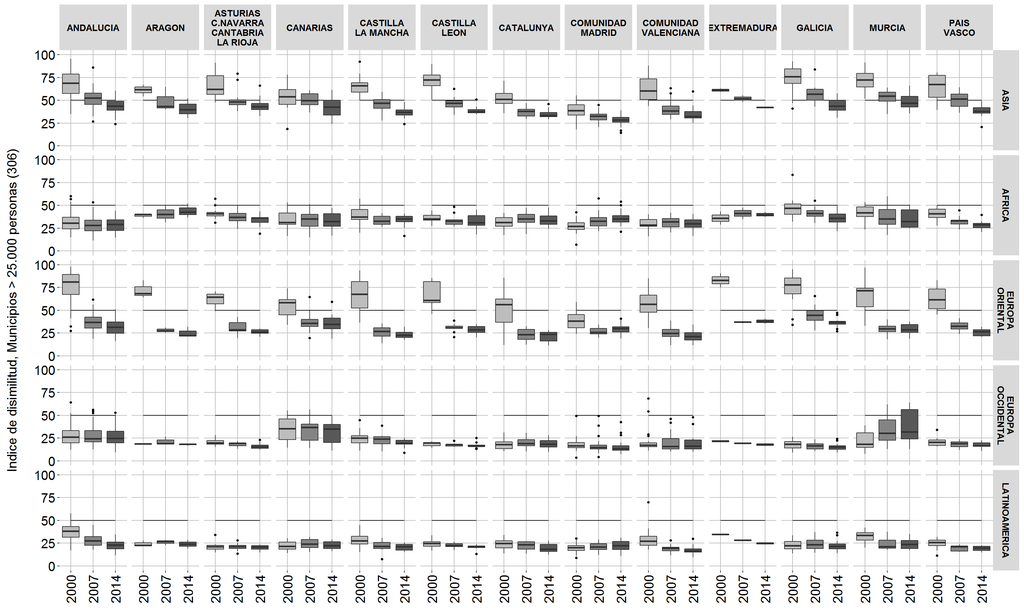

```r
load("C:\\Users\\jgaleano\\Desktop\\ICARIA\\DATOS_ICARIA_2.Rdata")

CODIGOS<-seg0111[(seg0111$TotPop>=25000&seg0111$year==2014&seg0111$AREAS>=10),1]
CODIGOS <-data.frame(CODIGOS)
colnames(CODIGOS)<-"CODMUN"

NOMBRES_MUNICIPIOS_2014_UTF <- read.csv("C:/Users/jgaleano/Dropbox/R/DATA/NOMBRES_MUNICIPIOS_2014_UTF.csv", stringsAsFactors=FALSE)
NOMBRES_MUNICIPIOS_2014_UTF<-NOMBRES_MUNICIPIOS_2014_UTF[,1:2]
colnames(NOMBRES_MUNICIPIOS_2014_UTF)<- c("Nom_Mun","CODMUN")
NOMBRES_MUNICIPIOS_2014_UTF$codmun <- sprintf("%.5d",NOMBRES_MUNICIPIOS_2014_UTF$CODMUN)

CODIGOS <- merge(CODIGOS,NOMBRES_MUNICIPIOS_2014_UTF, by="CODMUN")

SEG2b <- seg0111[seg0111$CODMUN %in% CODIGOS$CODMUN, ]
YEAR <-rep(SEG2b$year, 5)
COM <- rep(SEG2b$COM, 5)
CONT <- rep(c("LATINOAMERICA", "EUROPA\nOCCIDENTAL","EUROPA\nORIENTAL","AFRICA","ASIA"),each=663)
DIS<-c(SEG2b$D2,SEG2b$D3,SEG2b$D4,SEG2b$D5,SEG2b$D6)
IS<-c(SEG2b$IS2,SEG2b$IS3,SEG2b$IS4,SEG2b$IS5,SEG2b$IS6)

SEG <- data.frame(COM,YEAR,CONT,DIS,IS)
SEG <-SEG[!SEG$COM=="0",]
SEG$CONT <- factor(SEG$CONT,
                   levels = c("ASIA","AFRICA",
                              "EUROPA\nORIENTAL",
                              "EUROPA\nOCCIDENTAL",
                              "LATINOAMERICA"))

p <- ggplot(SEG, aes((YEAR), DIS))
A <-p + annotate("segment", x = 2000, xend =2014, y = 50, yend = 50,
        colour = "black", alpha=1,linetype=1)+
        geom_boxplot(aes(fill = factor(YEAR)), outlier.colour = "black", outlier.size = 1)+
        scale_y_continuous(limits = c(0, 100))+
        scale_x_continuous(breaks=c(2000, 2007,2014))+
        facet_grid(CONT ~ COM,scales = "free", space="free")+
        scale_fill_manual(values=c("#BDBDBD", "#848484","#585858"))+
        theme(plot.title = element_text(lineheight=5.6, size=20, face="bold"),
              legend.title = element_blank(),
              legend.text = element_text(colour="black", size = 20),
              legend.position="none",
              legend.background = element_rect(fill="#FFFFFF"),
              legend.justification=c(0,1),
              legend.key.size = unit(1, "cm"),
              axis.title.x = element_blank(),
              axis.text.x  = element_text(angle = 90,vjust=0.5, size=15,colour="black"),
              axis.title.y = element_text(colour="black", size=15),
              axis.text.y  = element_text(vjust=0.5, size=15,colour="black"),
              strip.text=element_text(angle = 0,vjust=0.5, size=10.5,colour="black", face = "bold"),
              panel.background = element_rect(fill = "#FFFFFF"),
              panel.grid = element_line(colour="#000000"),
              panel.grid.major=element_line(colour="#BDBDBD"),
              panel.grid.minor=element_line(colour="white"),
              plot.background = element_rect(fill = "#FFFFFF"))+
  ylab("Indice de disimilitud, Municipios > 25.000 personas (306)\n")
A
```

```r
setwd("C:\\Users\\jgaleano\\Desktop\\ICARIA\\GRAFICOS")
#ggsave("CAP1_FIG2_SEGREGACION_POR_COMUNIDAD_2000__2007_2014.tiff", scale = 3, width = 16.5, height = 8.8, units = c("cm"), dpi = 300)
```

#### **Figura 1.3: Estructura por sexo, edad y lugar de nacimiento de la población residente en enclaves, 2014**

#### **Municipio de Barcelona (Barcelona)[Pirámide superpuesta en términos relativos]**

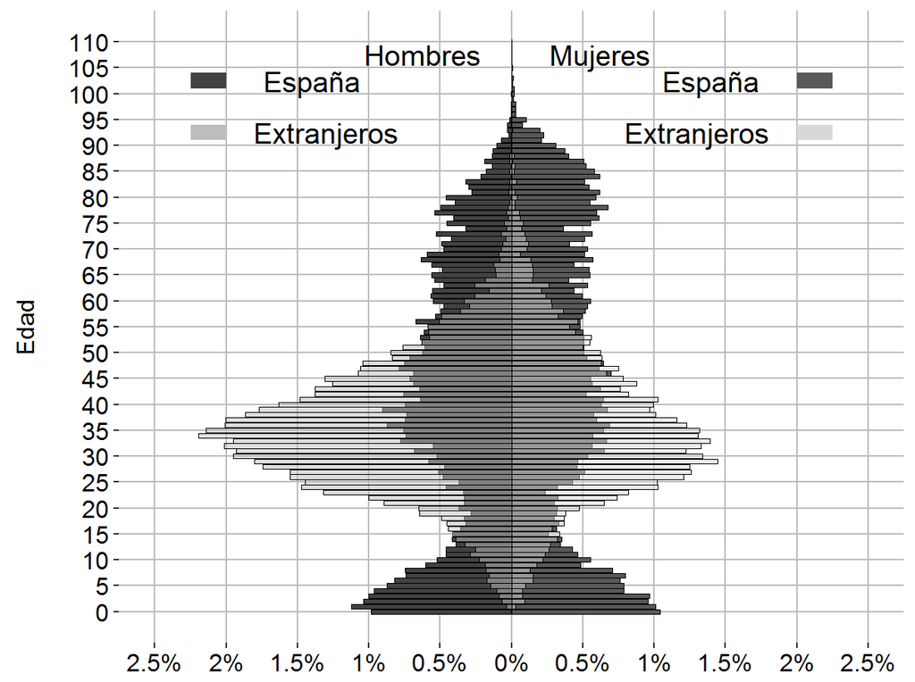

```r
library(ggplot2)
library(RColorBrewer)
require(dplyr)
library(scales)
AMB_EDADES_2014 <- read.csv("C:\\Users\\jgaleano\\Dropbox\\CSVs\\AMB_EDADES_2014.csv", sep=";", stringsAsFactors=FALSE)

# creo un codigo de indentificaciÃ³n (prov+mun+dist+secc) se fija la amplitud, poniendo 0s en frente:
AMB_EDADES_2014$provincia <- sprintf("%.2d",AMB_EDADES_2014$provincia) # prov tiene 2 digitos
AMB_EDADES_2014$municipio <- sprintf("%.5d",AMB_EDADES_2014$municipio)  # mun tiene 3 digitos
AMB_EDADES_2014$distrito  <- sprintf("%.2d",AMB_EDADES_2014$distrito) # dist tiene 2
AMB_EDADES_2014$seccion   <- sprintf("%.3d",AMB_EDADES_2014$seccion) # secc tiene 3
# concatenar
AMB_EDADES_2014$ID   <- with(AMB_EDADES_2014, paste(provincia, substr(municipio, 3,5), distrito, seccion, sep = "-"))
AMB_EDADES_2014$munnac <-NULL

AMB_EDADES_2014$nf <- ifelse(AMB_EDADES_2014$pronac < 66, "108",0)

AMB_EDADES_2014$REGION_NAC <- ifelse(AMB_EDADES_2014$nf == 108, "1",
                         ifelse(AMB_EDADES_2014$paisnac > 302 & AMB_EDADES_2014$paisnac < 400, "2",
                                ifelse(AMB_EDADES_2014$paisnac > 101 & AMB_EDADES_2014$paisnac < 104 |
                                         AMB_EDADES_2014$paisnac == 107 |
                                         AMB_EDADES_2014$paisnac > 108 & AMB_EDADES_2014$paisnac < 112 |
                                         AMB_EDADES_2014$paisnac > 112 & AMB_EDADES_2014$paisnac < 122 |
                                         AMB_EDADES_2014$paisnac > 122 & AMB_EDADES_2014$paisnac < 127 |
                                         AMB_EDADES_2014$paisnac > 128 & AMB_EDADES_2014$paisnac < 133, "3",
                                       ifelse(AMB_EDADES_2014$paisnac == 101 |
                                                AMB_EDADES_2014$paisnac == 112 |
                                                AMB_EDADES_2014$paisnac == 122 |
                                                AMB_EDADES_2014$paisnac == 128 |
                                                AMB_EDADES_2014$paisnac > 103 & AMB_EDADES_2014$paisnac < 107 |
                                                AMB_EDADES_2014$paisnac > 134 & AMB_EDADES_2014$paisnac < 200, "4",
                                              ifelse(AMB_EDADES_2014$paisnac > 200 & AMB_EDADES_2014$paisnac < 300, "5",
                                                     ifelse(AMB_EDADES_2014$paisnac > 400 & AMB_EDADES_2014$paisnac < 500, "6",
                                                            0))))))

AMB_EDADES_2014$nf<- NULL

AMB_EDADES_2014$REGION_NAC2 <- ifelse(AMB_EDADES_2014$REGION_NAC == "1", "ESP","EXT")

ENCLAVES <- c("08-019-01-002","08-019-01-005","08-019-01-006",
              "08-019-01-007","08-019-01-008","08-019-01-009","08-019-01-010",
              "08-019-01-011","08-019-01-012","08-019-01-014","08-019-01-015",
              "08-019-01-016","08-019-01-017","08-019-01-018","08-019-01-019",
              "08-019-01-026","08-019-01-029","08-019-01-031","08-019-01-051")


AMB_ENC<-  AMB_EDADES_2014[AMB_EDADES_2014$ID %in% ENCLAVES,]
b <- AMB_ENC %>%group_by(REGION_NAC2,sexo,edad) %>% tally()

#b <- AMB_ENC %>%group_by(REGION_NAC,paisnac,municipio) %>% tally()
b <- b[order(-b$n),]
ages <- data.frame(c(0:110))
colnames(ages)<- "edad"

HOMESP <-b[(b$REGION_NAC2=="ESP" & b$sexo==1),]
HOMESP<-merge(HOMESP,ages, by="edad",all = TRUE)
HOMESP$REGION_NAC2<- "ESP"
HOMESP$sexo<- "Hombres\nEspaña"
HOMESP[is.na(HOMESP)]<- 0

MUJESP <-b[(b$REGION_NAC2=="ESP" & b$sexo==6),]
MUJESP<-merge(MUJESP,ages, by="edad",all = TRUE)
MUJESP$REGION_NAC2<- "ESP"
MUJESP$sexo<- "Mujeres\nEspaña"
MUJESP[is.na(MUJESP)]<- 0


HOMEXT <-b[(b$REGION_NAC2=="EXT" & b$sexo==1),]
HOMEXT<-merge(HOMEXT,ages, by="edad",all = TRUE)
HOMEXT$REGION_NAC2<- "EXT"
HOMEXT$sexo<- "Hombres\nExtranjero"
HOMEXT[is.na(HOMEXT)]<- 0

MUJEXT <-b[(b$REGION_NAC2=="EXT" & b$sexo==6),]
MUJEXT<-merge(MUJEXT,ages, by="edad",all = TRUE)
MUJEXT$REGION_NAC2<- "EXT"
MUJEXT$sexo<- "Mujeres\nExtranjero"
MUJEXT[is.na(MUJEXT)]<- 0

HOMESP$nREL <- ((HOMESP$n/(sum(HOMESP$n)+sum(MUJESP$n)))*100)*-1
MUJESP$nREL <- MUJESP$n/(sum(HOMESP$n)+sum(MUJESP$n))*100
HOMEXT$nREL <- ((HOMEXT$n/(sum(HOMEXT$n)+sum(MUJEXT$n)))*100)*-1
MUJEXT$nREL <- MUJEXT$n/(sum(HOMEXT$n)+sum(MUJEXT$n))*100


ESP <- rbind(HOMESP,MUJESP,HOMEXT,MUJEXT)

A<- ggplot(ESP, aes(x=edad, y=nREL, fill=sexo))+
   geom_bar(data = ESP[(ESP$sexo=="Mujeres\nEspaña"|
                   ESP$sexo=="Hombres\nEspaña"),],
                   colour = I("Black"),stat="identity", position="identity", size=.3, colour="black",
                   aes(x = edad, y = nREL,fill = sexo), alpha = 1)+
   geom_bar(data = ESP[(ESP$sexo=="Hombres\nExtranjero"|
                          ESP$sexo=="Mujeres\nExtranjero"),],
            colour = I("Black"),stat="identity", position="identity", size=.3, colour="black",
            aes(x = edad, y = nREL,fill = sexo), alpha = .5)+
           coord_flip()+
 # facet_grid(. ~ TITOL)+
  scale_y_continuous(limits=c(-2.5,2.5),breaks = c(-2.5,-2,-1.5,-1,-0.5,0,0.5,1,1.5,2, 2.5),
                     labels = paste0(as.character(c(seq(2.5, 0, -0.5), seq(0.5, 2.5, 0.5))), "%")) +
           scale_x_continuous(breaks=seq(0,110,5)) +
           scale_fill_manual(values = c("#424242", "#BDBDBD","#585858", "#D8D8D8"))+
  annotate("text", x = 107.5, y = -2.5*.25, label = "Hombres",size=5)+
  annotate("text", x = 107.5, y = 2.5*0.25, label = "Mujeres",size=5)+
  annotate("rect", xmin = 101, xmax = 104, ymin = -2.5*.90, ymax =-2.5*.80, alpha=1, fill="#424242")+
  annotate("text", x = 102.5, y = -1.40, label = "España",size=5)+
  annotate("rect", xmin = 91, xmax = 94,  ymin = -2.5*.90, ymax =-2.5*.80,alpha=1, fill="#BDBDBD")+
  annotate("text", x = 92.5,  y = -1.30, label = "Extranjeros",size=5)+
  annotate("rect", xmin = 101, xmax = 104,  ymin = 2.5*.90, ymax =2.5*.80, alpha=1, fill="#585858")+
  annotate("text", x = 102.5, y = 1.40, label = "España",size=5)+
  annotate("rect", xmin = 91, xmax = 94, ymin = 2.5*.90, ymax =2.5*.80, alpha=1, fill="#D8D8D8")+
  annotate("text", x = 92.5,  y = 1.30, label = "Extranjeros",size=5)+
   theme(plot.title = element_text(lineheight=5.6, size=20, face="bold"),
              legend.title = element_blank(),
              legend.text = element_text(colour="black", size = 12),
              legend.position="none",
              legend.background = element_rect(fill="#FFFFFF"),
              legend.justification=c(0,1),
              legend.key.size = unit(1, "cm"),
              axis.title.x = element_blank(),
              axis.text.x  = element_text(angle = 0,vjust=0.5, size=12,colour="black"),
              axis.title.y = element_text(colour="black", size=12),
              axis.text.y  = element_text(vjust=0.5, size=12,colour="black"),
              strip.text=element_text(angle = 0,vjust=0.5, size=9,colour="black", face = "bold"),
              panel.background = element_rect(fill = "#FFFFFF"),
              panel.grid = element_line(colour="#000000"),
              panel.grid.major=element_line(colour="#BDBDBD"),
              panel.grid.minor=element_line(colour="white"),
              plot.background = element_rect(fill = "#FFFFFF"))+
  xlab("Edad\n")
A
```

```r
setwd("C:\\Users\\jgaleano\\Desktop\\ICARIA\\GRAFICOS")
#ggsave("CAP1_FIG3_PIRAMIDE_BARCELONA_RELATIVOS_2014.tiff", scale = 3, width = 6.3, height = 4.7, units = c("cm"), dpi = 300)
```

#### **Municipio de Barcelona (Barcelona)[Pirámide compuesta en términos absolutos]**

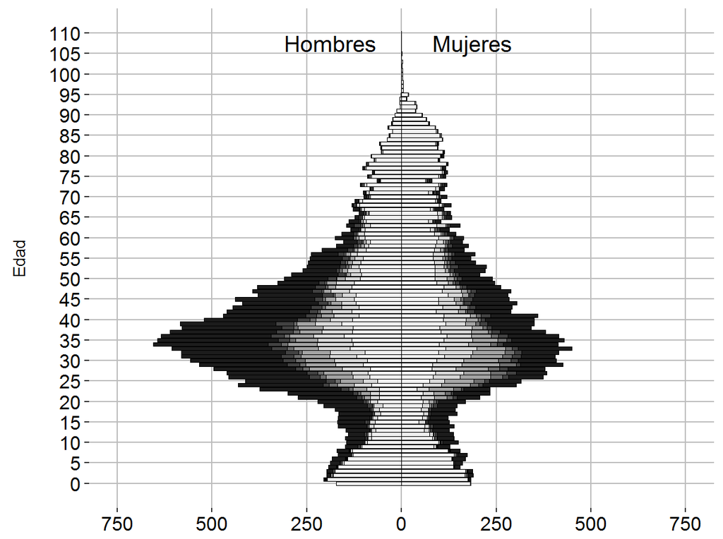

```r
AMB_ENC<-  AMB_EDADES_2014[AMB_EDADES_2014$ID %in% ENCLAVES,]
b <- AMB_ENC %>%group_by(REGION_NAC,sexo,edad) %>% tally()


ages <- data.frame(c(0:110))
colnames(ages)<- "edad"

HOMESP <-b[(b$REGION_NAC==1 & b$sexo==1),]
HOMESP<-merge(HOMESP,ages, by="edad",all = TRUE)
HOMESP$REGION_NAC<- 1
HOMESP$sexo<- "Hombres\nEspaña"
HOMESP[is.na(HOMESP)]<- 0

MUJESP <-b[(b$REGION_NAC==1 & b$sexo==6),]
MUJESP<-merge(MUJESP,ages, by="edad",all = TRUE)
MUJESP$REGION_NAC<- 1
MUJESP$sexo<- "Mujeres\nEspaña"
MUJESP[is.na(MUJESP)]<- 0


HOMLA <-b[(b$REGION_NAC==2 & b$sexo==1),]
HOMLA<-merge(HOMLA,ages, by="edad",all = TRUE)
HOMLA$REGION_NAC<- 2
HOMLA$sexo<- "Hombres\nLatinoamerica"
HOMLA[is.na(HOMLA)]<- 0

MUJLA <-b[(b$REGION_NAC==2 & b$sexo==6),]
MUJLA<-merge(MUJLA,ages, by="edad",all = TRUE)
MUJLA$REGION_NAC<- 2
MUJLA$sexo<- "Mujeres\nLatinoamerica"
MUJLA[is.na(MUJLA)]<- 0

HOMWE <-b[(b$REGION_NAC==3 & b$sexo==1),]
HOMWE<-merge(HOMWE,ages, by="edad",all = TRUE)
HOMWE$REGION_NAC<- 3
HOMWE<-HOMWE[1:111,]
HOMWE$sexo<- "Hombres\nEuropa_Occ."
HOMWE[is.na(HOMWE)]<- 0

MUJWE <-b[(b$REGION_NAC==3 & b$sexo==6),]
MUJWE<-merge(MUJWE,ages, by="edad",all = TRUE)
MUJWE$REGION_NAC<- 3
MUJWE$sexo<- "Mujeres\nEuropa_Occ."
MUJWE[is.na(MUJWE)]<- 0

HOMEE <-b[(b$REGION_NAC==4 & b$sexo==1),]
HOMEE<-merge(HOMEE,ages, by="edad",all = TRUE)
HOMEE$REGION_NAC<- 4
HOMEE$sexo<- "Hombres\nEuropa_Or."
HOMEE[is.na(HOMEE)]<- 0

MUJEE <-b[(b$REGION_NAC==4 & b$sexo==6),]
MUJEE<-merge(MUJEE,ages, by="edad",all = TRUE)
MUJEE$REGION_NAC<- 4
MUJEE$sexo<- "Mujeres\nEuropa_Or."
MUJEE[is.na(MUJEE)]<- 0

HOMAF <-b[(b$REGION_NAC==5 & b$sexo==1),]
HOMAF<-merge(HOMAF,ages, by="edad",all = TRUE)
HOMAF$REGION_NAC<- 5
HOMAF$sexo<- "Hombres\nAfrica"
HOMAF[is.na(HOMAF)]<- 0

MUJAF <-b[(b$REGION_NAC==5 & b$sexo==6),]
MUJAF<-merge(MUJAF,ages, by="edad",all = TRUE)
MUJAF$REGION_NAC<- 5
MUJAF$sexo<- "Mujeres\nAfrica"
MUJAF[is.na(MUJAF)]<- 0

HOMAS <-b[(b$REGION_NAC==6 & b$sexo==1),]
HOMAS<-merge(HOMAS,ages, by="edad",all = TRUE)
HOMAS$REGION_NAC<- 6
HOMAS$sexo<- "Hombres\nAsia"
HOMAS[is.na(HOMAS)]<- 0

MUJAS <-b[(b$REGION_NAC==6 & b$sexo==6),]
MUJAS<-merge(MUJAS,ages, by="edad",all = TRUE)
MUJAS$REGION_NAC<- 6
MUJAS$sexo<- "Mujeres\nAsia"
MUJAS[is.na(MUJAS)]<- 0

HOMOT <-b[(b$REGION_NAC==0 & b$sexo==1),]
HOMOT<-merge(HOMOT,ages, by="edad",all = TRUE)
HOMOT$REGION_NAC<- 0
HOMOT$sexo<- "Hombres\nOtros"
HOMOT[is.na(HOMOT)]<- 0

MUJOT <-b[(b$REGION_NAC==0 & b$sexo==6),]
MUJOT<-merge(MUJOT,ages, by="edad",all = TRUE)
MUJOT$REGION_NAC<- 0
MUJOT$sexo<- "Mujeres\nOtros"
MUJOT[is.na(MUJOT)]<- 0

HOMESP$n <- HOMESP$n*-1
HOMLA$n <- HOMLA$n*-1
HOMWE$n <- HOMWE$n*-1
HOMEE$n <- HOMEE$n*-1
HOMAF$n <- HOMAF$n*-1
HOMAS$n <- HOMAS$n*-1
HOMOT$n <- HOMOT$n*-1



ESP <- rbind(HOMESP,MUJESP,HOMLA,MUJLA,HOMWE, MUJWE, HOMEE,MUJEE,HOMAF,MUJAF,
             HOMAS,MUJAS,HOMOT,MUJOT)

ESP$SEXO2 <- substr(ESP$sexo, 9,25)

ESP$SEXO2<- factor(ESP$SEXO2,
                   levels = c("España", "Latinoamerica", "Europa_Occ.", "Europa_Or.", "Africa", "Asia", "Otros"))

A<-ggplot(ESP, aes(x=edad, y=n, fill=sexo))+
  geom_bar(data = ESP[(ESP$sexo=="Mujeres\nEspaña"|
                                         ESP$sexo=="Mujeres\nLatinoamerica"|
                                         ESP$sexo=="Mujeres\nEuropa_Occ."|
                                         ESP$sexo=="Mujeres\nEuropa_Or."|
                                         ESP$sexo=="Mujeres\nAfrica"|
                                         ESP$sexo=="Mujeres\nAsia"),],
           colour = I("Black"),stat="identity", size=.3, colour="black",
           aes(x = edad, y = n,fill = SEXO2), alpha = 1)+
  geom_bar(data = ESP[(ESP$sexo=="Hombres\nEspaña"|
                                           ESP$sexo=="Hombres\nLatinoamerica"|
                                           ESP$sexo=="Hombres\nEuropa_Occ."|
                                           ESP$sexo=="Hombres\nEuropa_Or."|
                                           ESP$sexo=="Hombres\nAfrica"|
                                           ESP$sexo=="Hombres\nAsia"),],
           colour = I("Black"),stat="identity", size=.3, colour="black",
           aes(x = edad, y = n,fill = SEXO2), alpha = 1)+
  coord_flip()+
 scale_y_continuous(limits=c(-750,750),breaks = c(-750, -500, -250,0,250,500,750),
                     labels = paste0(as.character(c(seq(750, 0, -250), seq(250, 750, 250))), "")) +
  scale_x_continuous(breaks=seq(0,110,5)) +
  scale_fill_manual(values = c("#F2F2F2","#D8D8D8","#A4A4A4","#6E6E6E",
                               "#424242","#1C1C1C"))+


  annotate("text", x = 107.5, y = -750*0.25,  label = "Hombres",size=5)+
  annotate("text", x = 107.5, y = 750*0.25, label = "Mujeres",size=5)+
   theme(plot.title = element_text(lineheight=5.6, size=10, face="bold"),
              legend.title = element_blank(),
              legend.text = element_text(colour="black", size = 12),
              legend.position="none",
              legend.background = element_rect(fill="#FFFFFF"),
              legend.justification=c(0,1),
              legend.key.size = unit(1, "cm"),
              axis.title.x = element_blank(),
              axis.text.x  = element_text(angle = 0,vjust=0.5, size=12,colour="black"),
              axis.title.y = element_text(colour="black", size=10),
              axis.text.y  = element_text(vjust=0.5, size=12,colour="black"),
              strip.text=element_text(angle = 0,vjust=0.5, size=9,colour="black", face = "bold"),
              panel.background = element_rect(fill = "#FFFFFF"),
              panel.grid = element_line(colour="#000000"),
              panel.grid.major=element_line(colour="#BDBDBD"),
              panel.grid.minor=element_line(colour="white"),
              plot.background = element_rect(fill = "#FFFFFF"))+
  xlab("Edad\n")
A
```

```r
setwd("C:\\Users\\jgaleano\\Desktop\\ICARIA\\GRAFICOS")
#ggsave("CAP1_FIG3_PIRAMIDE_BARCELONA_ABSOLUTOS_2014.tiff", scale = 3, width = 6.3, height = 4.7, units = c("cm"), dpi = 300)
```

#### **Municipios de las comarcas de Alt y Baix Marina y Baix Segura (Alicante)[Pirámide superpuesta en términos relativos]**

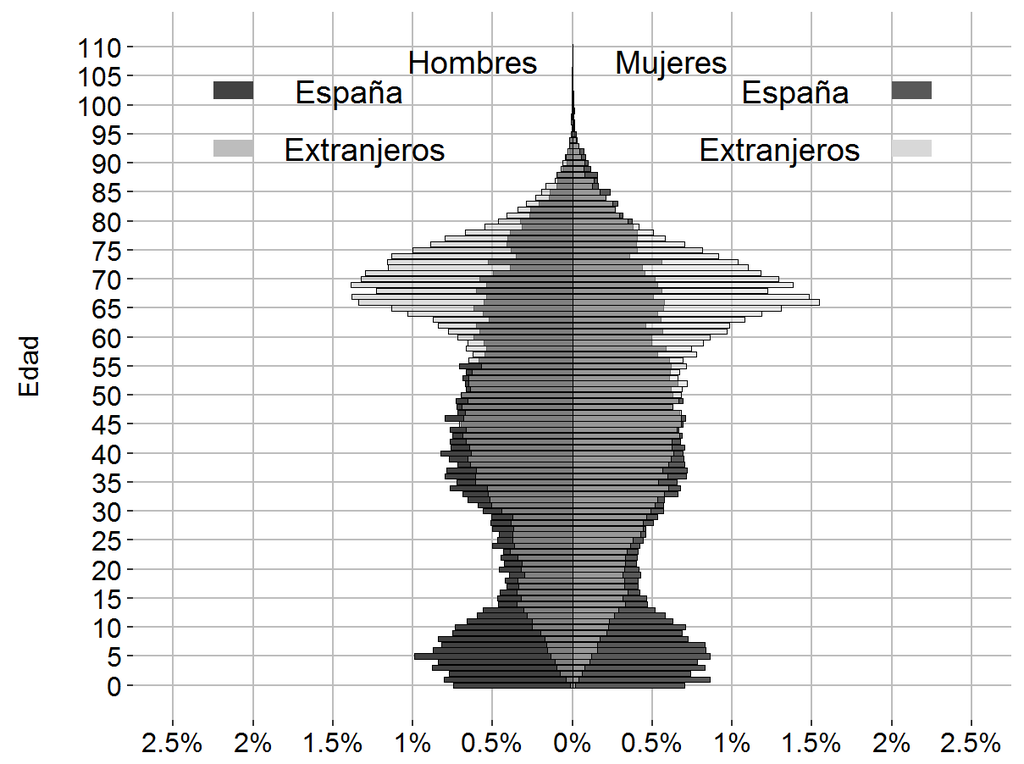

```r
library(ggplot2)
library(RColorBrewer)
require(dplyr)
library(scales)
AMB_EDADES_2014 <- read.csv("C:/Users/jgaleano/Dropbox/TESIS/3-RECERCAIXA/articulos libro/VAL_EDADES_2014.csv", sep=";", stringsAsFactors=FALSE)
# creo un codigo de indentificaciÃ³n (prov+mun+dist+secc) se fija la amplitud, poniendo 0s en frente:
AMB_EDADES_2014$provincia <- sprintf("%.2d",AMB_EDADES_2014$provincia) # prov tiene 2 digitos
AMB_EDADES_2014$municipio <- sprintf("%.5d",AMB_EDADES_2014$municipio)  # mun tiene 3 digitos
AMB_EDADES_2014$distrito  <- sprintf("%.2d",AMB_EDADES_2014$distrito) # dist tiene 2
AMB_EDADES_2014$seccion   <- sprintf("%.3d",AMB_EDADES_2014$seccion) # secc tiene 3
# concatenar
AMB_EDADES_2014$ID   <- with(AMB_EDADES_2014, paste(provincia, substr(municipio, 3,5), distrito, seccion, sep = "-"))
AMB_EDADES_2014$munnac <-NULL

AMB_EDADES_2014$nf <- ifelse(AMB_EDADES_2014$pronac < 66, "108",0)

AMB_EDADES_2014$REGION_NAC <- ifelse(AMB_EDADES_2014$nf == 108, "1",
                         ifelse(AMB_EDADES_2014$paisnac > 302 & AMB_EDADES_2014$paisnac < 400, "2",
                                ifelse(AMB_EDADES_2014$paisnac > 101 & AMB_EDADES_2014$paisnac < 104 |
                                         AMB_EDADES_2014$paisnac == 107 |
                                         AMB_EDADES_2014$paisnac > 108 & AMB_EDADES_2014$paisnac < 112 |
                                         AMB_EDADES_2014$paisnac > 112 & AMB_EDADES_2014$paisnac < 122 |
                                         AMB_EDADES_2014$paisnac > 122 & AMB_EDADES_2014$paisnac < 127 |
                                         AMB_EDADES_2014$paisnac > 128 & AMB_EDADES_2014$paisnac < 133, "3",
                                       ifelse(AMB_EDADES_2014$paisnac == 101 |
                                                AMB_EDADES_2014$paisnac == 112 |
                                                AMB_EDADES_2014$paisnac == 122 |
                                                AMB_EDADES_2014$paisnac == 128 |
                                                AMB_EDADES_2014$paisnac > 103 & AMB_EDADES_2014$paisnac < 107 |
                                                AMB_EDADES_2014$paisnac > 134 & AMB_EDADES_2014$paisnac < 200, "4",
                                              ifelse(AMB_EDADES_2014$paisnac > 200 & AMB_EDADES_2014$paisnac < 300, "5",
                                                     ifelse(AMB_EDADES_2014$paisnac > 400 & AMB_EDADES_2014$paisnac < 500, "6",
                                                            0))))))

AMB_EDADES_2014$nf<- NULL

AMB_EDADES_2014$REGION_NAC2 <- ifelse(AMB_EDADES_2014$REGION_NAC == "1", "ESP","EXT")

ENCLAVES <- c("03-006-01-001","03-011-01-002","03-011-01-004","03-011-01-005",
              "03-011-01-006","03-012-01-001","03-018-03-002","03-018-03-005",
              "03-029-01-001","03-031-02-003","03-031-02-006","03-031-02-007",
              "03-031-02-008","03-041-02-001","03-042-01-001","03-047-01-004",
              "03-047-02-001","03-047-02-002","03-062-01-001","03-070-01-002",
              "03-076-01-007","03-082-02-002","03-082-03-001","03-082-03-003",
              "03-085-01-001","03-094-01-003","03-094-01-004","03-094-01-007",
              "03-099-05-001","03-099-05-002","03-099-05-003","03-099-05-004",
              "03-113-01-002","03-118-01-002","03-120-01-002","03-133-01-006",
              "03-133-01-008","03-133-01-009","03-133-02-003","03-133-02-005",
              "03-133-02-007","03-133-02-009","03-133-03-004","03-133-03-006",
              "03-133-03-008","03-133-03-010","03-133-03-011","03-133-03-013",
              "03-133-03-014","03-133-03-015","03-139-03-005","03-139-03-006",
              "03-901-01-001","03-902-01-004","03-902-01-008")


AMB_ENC<-  AMB_EDADES_2014[AMB_EDADES_2014$ID %in% ENCLAVES,]
b <- AMB_ENC %>%group_by(REGION_NAC2,sexo,edad) %>% tally()

#b <- AMB_ENC %>%group_by(REGION_NAC,paisnac,municipio) %>% tally()
b <- b[order(-b$n),]
ages <- data.frame(c(0:110))
colnames(ages)<- "edad"

HOMESP <-b[(b$REGION_NAC2=="ESP" & b$sexo==1),]
HOMESP<-merge(HOMESP,ages, by="edad",all = TRUE)
HOMESP$REGION_NAC2<- "ESP"
HOMESP$sexo<- "Hombres\nEspaña"
HOMESP[is.na(HOMESP)]<- 0

MUJESP <-b[(b$REGION_NAC2=="ESP" & b$sexo==6),]
MUJESP<-merge(MUJESP,ages, by="edad",all = TRUE)
MUJESP$REGION_NAC2<- "ESP"
MUJESP$sexo<- "Mujeres\nEspaña"
MUJESP[is.na(MUJESP)]<- 0


HOMEXT <-b[(b$REGION_NAC2=="EXT" & b$sexo==1),]
HOMEXT<-HOMEXT[c(1:105),]
HOMEXT<-merge(HOMEXT,ages, by="edad",all = TRUE)
HOMEXT$REGION_NAC2<- "EXT"
HOMEXT$sexo<- "Hombres\nExtranjero"
HOMEXT[is.na(HOMEXT)]<- 0

MUJEXT <-b[(b$REGION_NAC2=="EXT" & b$sexo==6),]
MUJEXT<-merge(MUJEXT,ages, by="edad",all = TRUE)
MUJEXT$REGION_NAC2<- "EXT"
MUJEXT$sexo<- "Mujeres\nExtranjero"
MUJEXT[is.na(MUJEXT)]<- 0

HOMESP$nREL <- ((HOMESP$n/(sum(HOMESP$n)+sum(MUJESP$n)))*100)*-1
MUJESP$nREL <- MUJESP$n/(sum(HOMESP$n)+sum(MUJESP$n))*100
HOMEXT$nREL <- ((HOMEXT$n/(sum(HOMEXT$n)+sum(MUJEXT$n)))*100)*-1
MUJEXT$nREL <- MUJEXT$n/(sum(HOMEXT$n)+sum(MUJEXT$n))*100


ESP <- rbind(HOMESP,MUJESP,HOMEXT,MUJEXT)

A<- ggplot(ESP, aes(x=edad, y=nREL, fill=sexo))+
   geom_bar(data = ESP[(ESP$sexo=="Mujeres\nEspaña"|
                   ESP$sexo=="Hombres\nEspaña"),],
                   colour = I("Black"),stat="identity", position="identity", size=.3, colour="black",
                   aes(x = edad, y = nREL,fill = sexo), alpha = 1)+
   geom_bar(data = ESP[(ESP$sexo=="Hombres\nExtranjero"|
                          ESP$sexo=="Mujeres\nExtranjero"),],
            colour = I("Black"),stat="identity", position="identity", size=.3, colour="black",
            aes(x = edad, y = nREL,fill = sexo), alpha = .5)+
           coord_flip()+
 # facet_grid(. ~ TITOL)+
  scale_y_continuous(limits=c(-2.5,2.5),breaks = c(-2.5,-2,-1.5,-1,-0.5,0,0.5,1,1.5,2, 2.5),
                     labels = paste0(as.character(c(seq(2.5, 0, -0.5), seq(0.5, 2.5, 0.5))), "%")) +
           scale_x_continuous(breaks=seq(0,110,5)) +
           scale_fill_manual(values = c("#424242", "#BDBDBD","#585858", "#D8D8D8"))+
    annotate("text", x = 107.5, y = -2.5*.25, label = "Hombres",size=5)+
  annotate("text", x = 107.5, y = 2.5*0.25, label = "Mujeres",size=5)+
  annotate("rect", xmin = 101, xmax = 104, ymin = -2.5*.90, ymax =-2.5*.80, alpha=1, fill="#424242")+
  annotate("text", x = 102.5, y = -1.40, label = "España",size=5)+
  annotate("rect", xmin = 91, xmax = 94,  ymin = -2.5*.90, ymax =-2.5*.80,alpha=1, fill="#BDBDBD")+
  annotate("text", x = 92.5,  y = -1.30, label = "Extranjeros",size=5)+
  annotate("rect", xmin = 101, xmax = 104,  ymin = 2.5*.90, ymax =2.5*.80, alpha=1, fill="#585858")+
  annotate("text", x = 102.5, y = 1.40, label = "España",size=5)+
  annotate("rect", xmin = 91, xmax = 94, ymin = 2.5*.90, ymax =2.5*.80, alpha=1, fill="#D8D8D8")+
  annotate("text", x = 92.5,  y = 1.30, label = "Extranjeros",size=5)+
   theme(plot.title = element_text(lineheight=5.6, size=20, face="bold"),
              legend.title = element_blank(),
              legend.text = element_text(colour="black", size = 12),
              legend.position="none",
              legend.background = element_rect(fill="#FFFFFF"),
              legend.justification=c(0,1),
              legend.key.size = unit(1, "cm"),
              axis.title.x = element_blank(),
              axis.text.x  = element_text(angle = 0,vjust=0.5, size=12,colour="black"),
              axis.title.y = element_text(colour="black", size=12),
              axis.text.y  = element_text(vjust=0.5, size=12,colour="black"),
              strip.text=element_text(angle = 0,vjust=0.5, size=9,colour="black", face = "bold"),
              panel.background = element_rect(fill = "#FFFFFF"),
              panel.grid = element_line(colour="#000000"),
              panel.grid.major=element_line(colour="#BDBDBD"),
              panel.grid.minor=element_line(colour="white"),
              plot.background = element_rect(fill = "#FFFFFF"))+
  xlab("Edad\n")
A
```

```r
setwd("C:\\Users\\jgaleano\\Desktop\\ICARIA\\GRAFICOS")
#ggsave("CAP1_FIG3_PIRAMIDE_VALENCIA_RELATIVOS_2014.tiff", scale = 3, width = 6.3, height = 4.7, units = c("cm"), dpi = 300)
```

#### **Municipios de las comarcas de Alt y Baix Marina y Baix Segura (Alicante)[Pirámide compuesta en términos absolutos]**

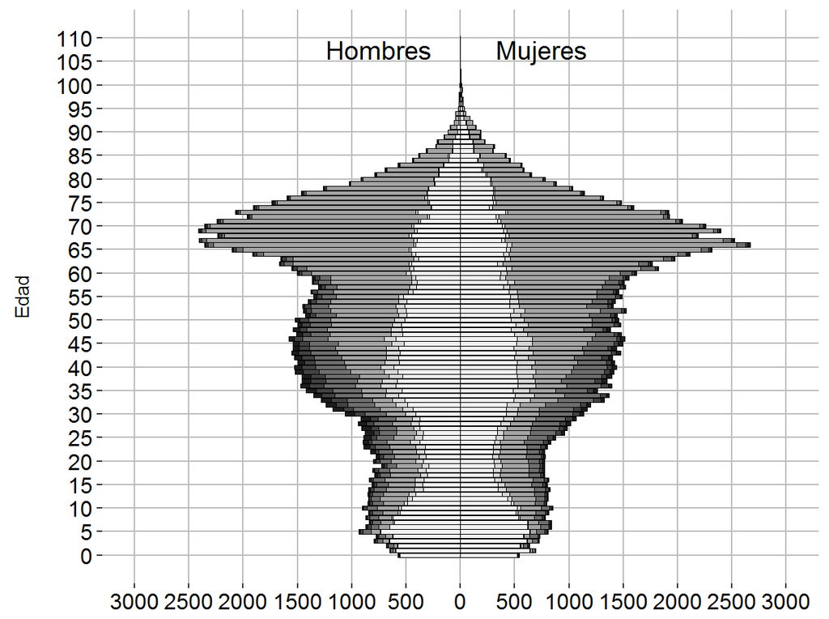

```r
AMB_ENC<-  AMB_EDADES_2014[AMB_EDADES_2014$ID %in% ENCLAVES,]
b <- AMB_ENC %>%group_by(REGION_NAC,sexo,edad) %>% tally()


ages <- data.frame(c(0:110))
colnames(ages)<- "edad"

HOMESP <-b[(b$REGION_NAC==1 & b$sexo==1),]
HOMESP<-merge(HOMESP,ages, by="edad",all = TRUE)
HOMESP$REGION_NAC<- 1
HOMESP$sexo<- "Hombres\nEspaña"
HOMESP[is.na(HOMESP)]<- 0

MUJESP <-b[(b$REGION_NAC==1 & b$sexo==6),]
MUJESP<-merge(MUJESP,ages, by="edad",all = TRUE)
MUJESP$REGION_NAC<- 1
MUJESP$sexo<- "Mujeres\nEspaña"
MUJESP[is.na(MUJESP)]<- 0


HOMLA <-b[(b$REGION_NAC==2 & b$sexo==1),]
HOMLA<-merge(HOMLA,ages, by="edad",all = TRUE)
HOMLA$REGION_NAC<- 2
HOMLA$sexo<- "Hombres\nLatinoamerica"
HOMLA[is.na(HOMLA)]<- 0

MUJLA <-b[(b$REGION_NAC==2 & b$sexo==6),]
MUJLA<-merge(MUJLA,ages, by="edad",all = TRUE)
MUJLA$REGION_NAC<- 2
MUJLA$sexo<- "Mujeres\nLatinoamerica"
MUJLA[is.na(MUJLA)]<- 0

HOMWE <-b[(b$REGION_NAC==3 & b$sexo==1),]
HOMWE<-merge(HOMWE,ages, by="edad",all = TRUE)
HOMWE$REGION_NAC<- 3
HOMWE<-HOMWE[1:111,]
HOMWE$sexo<- "Hombres\nEuropa_Occ."
HOMWE[is.na(HOMWE)]<- 0

MUJWE <-b[(b$REGION_NAC==3 & b$sexo==6),]
MUJWE<-merge(MUJWE,ages, by="edad",all = TRUE)
MUJWE$REGION_NAC<- 3
MUJWE$sexo<- "Mujeres\nEuropa_Occ."
MUJWE[is.na(MUJWE)]<- 0

HOMEE <-b[(b$REGION_NAC==4 & b$sexo==1),]
HOMEE<-merge(HOMEE,ages, by="edad",all = TRUE)
HOMEE$REGION_NAC<- 4
HOMEE$sexo<- "Hombres\nEuropa_Or."
HOMEE[is.na(HOMEE)]<- 0

MUJEE <-b[(b$REGION_NAC==4 & b$sexo==6),]
MUJEE<-merge(MUJEE,ages, by="edad",all = TRUE)
MUJEE$REGION_NAC<- 4
MUJEE$sexo<- "Mujeres\nEuropa_Or."
MUJEE[is.na(MUJEE)]<- 0

HOMAF <-b[(b$REGION_NAC==5 & b$sexo==1),]
HOMAF<-merge(HOMAF,ages, by="edad",all = TRUE)
HOMAF$REGION_NAC<- 5
HOMAF$sexo<- "Hombres\nAfrica"
HOMAF[is.na(HOMAF)]<- 0

MUJAF <-b[(b$REGION_NAC==5 & b$sexo==6),]
MUJAF<-merge(MUJAF,ages, by="edad",all = TRUE)
MUJAF$REGION_NAC<- 5
MUJAF$sexo<- "Mujeres\nAfrica"
MUJAF[is.na(MUJAF)]<- 0

HOMAS <-b[(b$REGION_NAC==6 & b$sexo==1),]
HOMAS<-merge(HOMAS,ages, by="edad",all = TRUE)
HOMAS$REGION_NAC<- 6
HOMAS$sexo<- "Hombres\nAsia"
HOMAS[is.na(HOMAS)]<- 0

MUJAS <-b[(b$REGION_NAC==6 & b$sexo==6),]
MUJAS<-merge(MUJAS,ages, by="edad",all = TRUE)
MUJAS$REGION_NAC<- 6
MUJAS$sexo<- "Mujeres\nAsia"
MUJAS[is.na(MUJAS)]<- 0

HOMOT <-b[(b$REGION_NAC==0 & b$sexo==1),]
HOMOT<-merge(HOMOT,ages, by="edad",all = TRUE)
HOMOT$REGION_NAC<- 0
HOMOT$sexo<- "Hombres\nOtros"
HOMOT[is.na(HOMOT)]<- 0

MUJOT <-b[(b$REGION_NAC==0 & b$sexo==6),]
MUJOT<-merge(MUJOT,ages, by="edad",all = TRUE)
MUJOT$REGION_NAC<- 0
MUJOT$sexo<- "Mujeres\nOtros"
MUJOT[is.na(MUJOT)]<- 0

HOMESP$n <- HOMESP$n*-1
HOMLA$n <- HOMLA$n*-1
HOMWE$n <- HOMWE$n*-1
HOMEE$n <- HOMEE$n*-1
HOMAF$n <- HOMAF$n*-1
HOMAS$n <- HOMAS$n*-1
HOMOT$n <- HOMOT$n*-1



ESP <- rbind(HOMESP,MUJESP,HOMLA,MUJLA,HOMWE, MUJWE, HOMEE,MUJEE,HOMAF,MUJAF,
             HOMAS,MUJAS,HOMOT,MUJOT)

ESP$SEXO2 <- substr(ESP$sexo, 9,25)

ESP$SEXO2<- factor(ESP$SEXO2,
                   levels = c("España", "Latinoamerica", "Europa_Occ.", "Europa_Or.", "Africa", "Asia", "Otros"))

A<-ggplot(ESP, aes(x=edad, y=n, fill=sexo))+
  geom_bar(data = ESP[(ESP$sexo=="Mujeres\nEspaña"|
                                         ESP$sexo=="Mujeres\nLatinoamerica"|
                                         ESP$sexo=="Mujeres\nEuropa_Occ."|
                                         ESP$sexo=="Mujeres\nEuropa_Or."|
                                         ESP$sexo=="Mujeres\nAfrica"|
                                         ESP$sexo=="Mujeres\nAsia"),],
           colour = I("Black"),stat="identity", size=.3, colour="black",
           aes(x = edad, y = n,fill = SEXO2), alpha = 1)+
  geom_bar(data = ESP[(ESP$sexo=="Hombres\nEspaña"|
                                           ESP$sexo=="Hombres\nLatinoamerica"|
                                           ESP$sexo=="Hombres\nEuropa_Occ."|
                                           ESP$sexo=="Hombres\nEuropa_Or."|
                                           ESP$sexo=="Hombres\nAfrica"|
                                           ESP$sexo=="Hombres\nAsia"),],
           colour = I("Black"),stat="identity", size=.3, colour="black",
           aes(x = edad, y = n,fill = SEXO2), alpha = 1)+
  coord_flip()+
  scale_y_continuous(limits=c(-3000,3000),breaks = c(-3000,-2500, -2000, -1500,-1000,-500, 0,500,1000,1500,2000,2500, 3000),
                     labels = paste0(as.character(c(seq(3000, 0, -500), seq(500, 3000, 500))), "")) +
  scale_x_continuous(breaks=seq(0,110,5)) +
  annotate("text", x = 107.5, y = -3000*0.25, label = "Hombres",size=5)+
  annotate("text", x = 107.5, y = 3000*0.25, label = "Mujeres",size=5)+

  scale_x_continuous(breaks=seq(0,110,5)) +
  scale_fill_manual(values = c("#F2F2F2","#D8D8D8","#A4A4A4","#6E6E6E",
                               "#424242","#1C1C1C"))+
   theme(plot.title = element_text(lineheight=5.6, size=10, face="bold"),
              legend.title = element_blank(),
              legend.text = element_text(colour="black", size = 12),
              legend.position="none",
              legend.background = element_rect(fill="#FFFFFF"),
              legend.justification=c(0,1),
              legend.key.size = unit(1, "cm"),
              axis.title.x = element_blank(),
              axis.text.x  = element_text(angle = 0,vjust=0.5, size=12,colour="black"),
              axis.title.y = element_text(colour="black", size=10),
              axis.text.y  = element_text(vjust=0.5, size=12,colour="black"),
              strip.text=element_text(angle = 0,vjust=0.5, size=9,colour="black", face = "bold"),
              panel.background = element_rect(fill = "#FFFFFF"),
              panel.grid = element_line(colour="#000000"),
              panel.grid.major=element_line(colour="#BDBDBD"),
              panel.grid.minor=element_line(colour="white"),
              plot.background = element_rect(fill = "#FFFFFF"))+
  xlab("Edad\n")
A
```

```r
setwd("C:\\Users\\jgaleano\\Desktop\\ICARIA\\GRAFICOS")
#ggsave("CAP1_FIG3_PIRAMIDE_VALENCIA_ABSOLUTOS_2014.tiff", scale = 3, width = 6.3, height = 4.7, units = c("cm"), dpi = 300)
```

#### **Arona y Adeje (Canarias)[Pirámide superpuesta en términos relativos]**

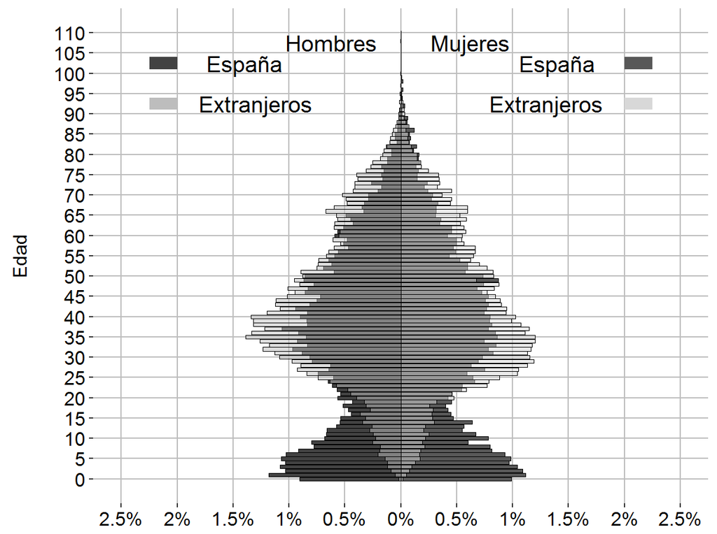

```r
library(ggplot2)
library(RColorBrewer)
require(dplyr)
library(scales)
AMB_EDADES_2014 <- read.csv("C:/Users/jgaleano/Dropbox/TESIS/3-RECERCAIXA/articulos libro/CAN_EDADES_2014.csv", sep=";", stringsAsFactors=FALSE)
AMB_EDADES_2014$provincia <- sprintf("%.2d",AMB_EDADES_2014$provincia) # prov tiene 2 digitos
AMB_EDADES_2014$municipio <- sprintf("%.5d",AMB_EDADES_2014$municipio)  # mun tiene 3 digitos
AMB_EDADES_2014$distrito  <- sprintf("%.2d",AMB_EDADES_2014$distrito) # dist tiene 2
AMB_EDADES_2014$seccion   <- sprintf("%.3d",AMB_EDADES_2014$seccion) # secc tiene 3
# concatenar
AMB_EDADES_2014$ID   <- with(AMB_EDADES_2014, paste(provincia, substr(municipio, 3,5), distrito, seccion, sep = "-"))
AMB_EDADES_2014$munnac <-NULL

AMB_EDADES_2014$nf <- ifelse(AMB_EDADES_2014$pronac < 66, "108",0)

AMB_EDADES_2014$REGION_NAC <- ifelse(AMB_EDADES_2014$nf == 108, "1",
                         ifelse(AMB_EDADES_2014$paisnac > 302 & AMB_EDADES_2014$paisnac < 400, "2",
                                ifelse(AMB_EDADES_2014$paisnac > 101 & AMB_EDADES_2014$paisnac < 104 |
                                         AMB_EDADES_2014$paisnac == 107 |
                                         AMB_EDADES_2014$paisnac > 108 & AMB_EDADES_2014$paisnac < 112 |
                                         AMB_EDADES_2014$paisnac > 112 & AMB_EDADES_2014$paisnac < 122 |
                                         AMB_EDADES_2014$paisnac > 122 & AMB_EDADES_2014$paisnac < 127 |
                                         AMB_EDADES_2014$paisnac > 128 & AMB_EDADES_2014$paisnac < 133, "3",
                                       ifelse(AMB_EDADES_2014$paisnac == 101 |
                                                AMB_EDADES_2014$paisnac == 112 |
                                                AMB_EDADES_2014$paisnac == 122 |
                                                AMB_EDADES_2014$paisnac == 128 |
                                                AMB_EDADES_2014$paisnac > 103 & AMB_EDADES_2014$paisnac < 107 |
                                                AMB_EDADES_2014$paisnac > 134 & AMB_EDADES_2014$paisnac < 200, "4",
                                              ifelse(AMB_EDADES_2014$paisnac > 200 & AMB_EDADES_2014$paisnac < 300, "5",
                                                     ifelse(AMB_EDADES_2014$paisnac > 400 & AMB_EDADES_2014$paisnac < 500, "6",
                                                            0))))))

AMB_EDADES_2014$nf<- NULL

AMB_EDADES_2014$REGION_NAC2 <- ifelse(AMB_EDADES_2014$REGION_NAC == "1", "ESP","EXT")
ENCLAVES <- c("38-001-01-003","38-001-01-007","38-001-01-008","38-001-01-011",
              "38-001-01-013","38-001-01-017","38-001-01-018","38-006-01-005",
              "38-006-01-006","38-006-01-007","38-006-01-011","38-006-01-014",
              "38-006-01-015","38-006-01-016","38-006-01-018","38-006-01-019",
              "38-006-01-020","38-006-01-023","38-006-01-026","38-006-01-029",
              "38-006-01-031")

AMB_ENC<-  AMB_EDADES_2014[AMB_EDADES_2014$ID %in% ENCLAVES,]
b <- AMB_ENC %>%group_by(REGION_NAC2,sexo,edad) %>% tally()

b <- b[order(-b$n),]
ages <- data.frame(c(0:110))
colnames(ages)<- "edad"

HOMESP <-b[(b$REGION_NAC2=="ESP" & b$sexo==1),]
HOMESP<-merge(HOMESP,ages, by="edad",all = TRUE)
HOMESP$REGION_NAC2<- "ESP"
HOMESP$sexo<- "Hombres\nEspaña"
HOMESP[is.na(HOMESP)]<- 0

MUJESP <-b[(b$REGION_NAC2=="ESP" & b$sexo==6),]
MUJESP<-merge(MUJESP,ages, by="edad",all = TRUE)
MUJESP$REGION_NAC2<- "ESP"
MUJESP$sexo<- "Mujeres\nEspaña"
MUJESP[is.na(MUJESP)]<- 0


HOMEXT <-b[(b$REGION_NAC2=="EXT" & b$sexo==1),]
HOMEXT<-merge(HOMEXT,ages, by="edad",all = TRUE)
HOMEXT$REGION_NAC2<- "EXT"
HOMEXT$sexo<- "Hombres\nExtranjero"
HOMEXT[is.na(HOMEXT)]<- 0

MUJEXT <-b[(b$REGION_NAC2=="EXT" & b$sexo==6),]
MUJEXT<-merge(MUJEXT,ages, by="edad",all = TRUE)
MUJEXT$REGION_NAC2<- "EXT"
MUJEXT$sexo<- "Mujeres\nExtranjero"
MUJEXT[is.na(MUJEXT)]<- 0

HOMESP$nREL <- ((HOMESP$n/(sum(HOMESP$n)+sum(MUJESP$n)))*100)*-1
MUJESP$nREL <- MUJESP$n/(sum(HOMESP$n)+sum(MUJESP$n))*100
HOMEXT$nREL <- ((HOMEXT$n/(sum(HOMEXT$n)+sum(MUJEXT$n)))*100)*-1
MUJEXT$nREL <- MUJEXT$n/(sum(HOMEXT$n)+sum(MUJEXT$n))*100


ESP <- rbind(HOMESP,MUJESP,HOMEXT,MUJEXT)

A<- ggplot(ESP, aes(x=edad, y=nREL, fill=sexo))+
   geom_bar(data = ESP[(ESP$sexo=="Mujeres\nEspaña"|
                   ESP$sexo=="Hombres\nEspaña"),],
                   colour = I("Black"),stat="identity", position="identity", size=.3, colour="black",
                   aes(x = edad, y = nREL,fill = sexo), alpha = 1)+
   geom_bar(data = ESP[(ESP$sexo=="Hombres\nExtranjero"|
                          ESP$sexo=="Mujeres\nExtranjero"),],
            colour = I("Black"),stat="identity", position="identity", size=.3, colour="black",
            aes(x = edad, y = nREL,fill = sexo), alpha = .5)+
           coord_flip()+
  scale_y_continuous(limits=c(-2.5,2.5),breaks = c(-2.5,-2,-1.5,-1,-0.5,0,0.5,1,1.5,2, 2.5),
                     labels = paste0(as.character(c(seq(2.5, 0, -0.5), seq(0.5, 2.5, 0.5))), "%")) +
           scale_x_continuous(breaks=seq(0,110,5)) +
           scale_fill_manual(values = c("#424242", "#BDBDBD","#585858", "#D8D8D8"))+
  annotate("text", x = 107.5, y = -2.5*.25, label = "Hombres",size=5)+
  annotate("text", x = 107.5, y = 2.5*0.25, label = "Mujeres",size=5)+
  annotate("rect", xmin = 101, xmax = 104, ymin = -2.5*.90, ymax =-2.5*.80, alpha=1, fill="#424242")+
  annotate("text", x = 102.5, y = -1.40, label = "España",size=5)+
  annotate("rect", xmin = 91, xmax = 94,  ymin = -2.5*.90, ymax =-2.5*.80,alpha=1, fill="#BDBDBD")+
  annotate("text", x = 92.5,  y = -1.30, label = "Extranjeros",size=5)+
  annotate("rect", xmin = 101, xmax = 104,  ymin = 2.5*.90, ymax =2.5*.80, alpha=1, fill="#585858")+
  annotate("text", x = 102.5, y = 1.40, label = "España",size=5)+
  annotate("rect", xmin = 91, xmax = 94, ymin = 2.5*.90, ymax =2.5*.80, alpha=1, fill="#D8D8D8")+
  annotate("text", x = 92.5,  y = 1.30, label = "Extranjeros",size=5)+
   theme(plot.title = element_text(lineheight=5.6, size=20, face="bold"),
              legend.title = element_blank(),
              legend.text = element_text(colour="black", size = 12),
              legend.position="none",
              legend.background = element_rect(fill="#FFFFFF"),
              legend.justification=c(0,1),
              legend.key.size = unit(1, "cm"),
              axis.title.x = element_blank(),
              axis.text.x  = element_text(angle = 0,vjust=0.5, size=12,colour="black"),
              axis.title.y = element_text(colour="black", size=12),
              axis.text.y  = element_text(vjust=0.5, size=12,colour="black"),
              strip.text=element_text(angle = 0,vjust=0.5, size=9,colour="black", face = "bold"),
              panel.background = element_rect(fill = "#FFFFFF"),
              panel.grid = element_line(colour="#000000"),
              panel.grid.major=element_line(colour="#BDBDBD"),
              panel.grid.minor=element_line(colour="white"),
              plot.background = element_rect(fill = "#FFFFFF"))+
  xlab("Edad\n")
A
```

```r
setwd("C:\\Users\\jgaleano\\Desktop\\ICARIA\\GRAFICOS")
#ggsave("CAP1_FIG3_PIRAMIDE_CANARIAS_RELATIVOS_2014.tiff", scale = 3, width = 6.3, height = 4.7, units = c("cm"), dpi = 300)
```

#### **Arona y Adeje (Canarias)[Pirámide compuesta en términos absolutos]**

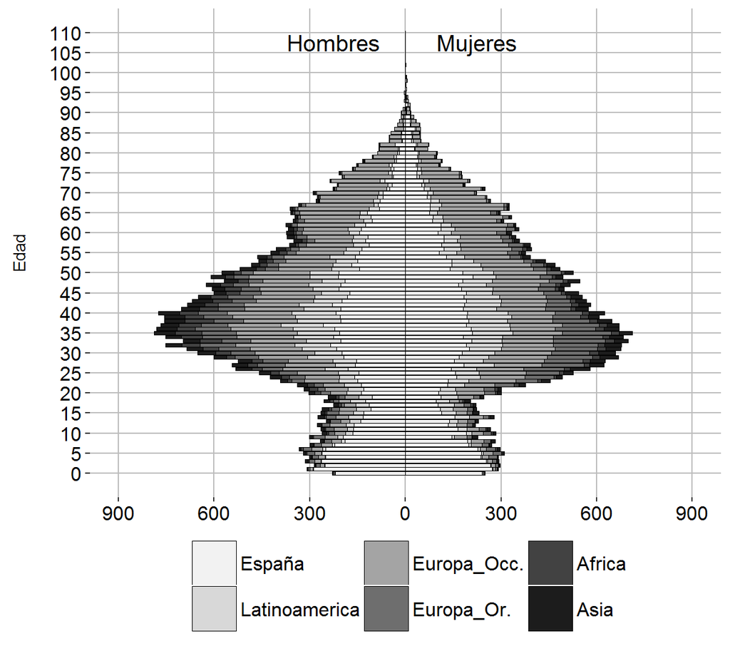

```r
AMB_ENC<-  AMB_EDADES_2014[AMB_EDADES_2014$ID %in% ENCLAVES,]
b <- AMB_ENC %>%group_by(REGION_NAC,sexo,edad) %>% tally()


ages <- data.frame(c(0:110))
colnames(ages)<- "edad"

HOMESP <-b[(b$REGION_NAC==1 & b$sexo==1),]
HOMESP<-merge(HOMESP,ages, by="edad",all = TRUE)
HOMESP$REGION_NAC<- 1
HOMESP$sexo<- "Hombres\nEspaña"
HOMESP[is.na(HOMESP)]<- 0

MUJESP <-b[(b$REGION_NAC==1 & b$sexo==6),]
MUJESP<-merge(MUJESP,ages, by="edad",all = TRUE)
MUJESP$REGION_NAC<- 1
MUJESP$sexo<- "Mujeres\nEspaña"
MUJESP[is.na(MUJESP)]<- 0


HOMLA <-b[(b$REGION_NAC==2 & b$sexo==1),]
HOMLA<-merge(HOMLA,ages, by="edad",all = TRUE)
HOMLA$REGION_NAC<- 2
HOMLA$sexo<- "Hombres\nLatinoamerica"
HOMLA[is.na(HOMLA)]<- 0

MUJLA <-b[(b$REGION_NAC==2 & b$sexo==6),]
MUJLA<-merge(MUJLA,ages, by="edad",all = TRUE)
MUJLA$REGION_NAC<- 2
MUJLA$sexo<- "Mujeres\nLatinoamerica"
MUJLA[is.na(MUJLA)]<- 0

HOMWE <-b[(b$REGION_NAC==3 & b$sexo==1),]
HOMWE<-merge(HOMWE,ages, by="edad",all = TRUE)
HOMWE$REGION_NAC<- 3
HOMWE<-HOMWE[1:111,]
HOMWE$sexo<- "Hombres\nEuropa_Occ."
HOMWE[is.na(HOMWE)]<- 0

MUJWE <-b[(b$REGION_NAC==3 & b$sexo==6),]
MUJWE<-merge(MUJWE,ages, by="edad",all = TRUE)
MUJWE$REGION_NAC<- 3
MUJWE$sexo<- "Mujeres\nEuropa_Occ."
MUJWE[is.na(MUJWE)]<- 0

HOMEE <-b[(b$REGION_NAC==4 & b$sexo==1),]
HOMEE<-merge(HOMEE,ages, by="edad",all = TRUE)
HOMEE$REGION_NAC<- 4
HOMEE$sexo<- "Hombres\nEuropa_Or."
HOMEE[is.na(HOMEE)]<- 0

MUJEE <-b[(b$REGION_NAC==4 & b$sexo==6),]
MUJEE<-merge(MUJEE,ages, by="edad",all = TRUE)
MUJEE$REGION_NAC<- 4
MUJEE$sexo<- "Mujeres\nEuropa_Or."
MUJEE[is.na(MUJEE)]<- 0

HOMAF <-b[(b$REGION_NAC==5 & b$sexo==1),]
HOMAF<-merge(HOMAF,ages, by="edad",all = TRUE)
HOMAF$REGION_NAC<- 5
HOMAF$sexo<- "Hombres\nAfrica"
HOMAF[is.na(HOMAF)]<- 0

MUJAF <-b[(b$REGION_NAC==5 & b$sexo==6),]
MUJAF<-merge(MUJAF,ages, by="edad",all = TRUE)
MUJAF$REGION_NAC<- 5
MUJAF$sexo<- "Mujeres\nAfrica"
MUJAF[is.na(MUJAF)]<- 0

HOMAS <-b[(b$REGION_NAC==6 & b$sexo==1),]
HOMAS<-merge(HOMAS,ages, by="edad",all = TRUE)
HOMAS$REGION_NAC<- 6
HOMAS$sexo<- "Hombres\nAsia"
HOMAS[is.na(HOMAS)]<- 0

MUJAS <-b[(b$REGION_NAC==6 & b$sexo==6),]
MUJAS<-merge(MUJAS,ages, by="edad",all = TRUE)
MUJAS$REGION_NAC<- 6
MUJAS$sexo<- "Mujeres\nAsia"
MUJAS[is.na(MUJAS)]<- 0

HOMOT <-b[(b$REGION_NAC==0 & b$sexo==1),]
HOMOT<-merge(HOMOT,ages, by="edad",all = TRUE)
HOMOT$REGION_NAC<- 0
HOMOT$sexo<- "Hombres\nOtros"
HOMOT[is.na(HOMOT)]<- 0

MUJOT <-b[(b$REGION_NAC==0 & b$sexo==6),]
MUJOT<-merge(MUJOT,ages, by="edad",all = TRUE)
MUJOT$REGION_NAC<- 0
MUJOT$sexo<- "Mujeres\nOtros"
MUJOT[is.na(MUJOT)]<- 0

HOMESP$n <- HOMESP$n*-1
HOMLA$n <- HOMLA$n*-1
HOMWE$n <- HOMWE$n*-1
HOMEE$n <- HOMEE$n*-1
HOMAF$n <- HOMAF$n*-1
HOMAS$n <- HOMAS$n*-1
HOMOT$n <- HOMOT$n*-1



ESP <- rbind(HOMESP,MUJESP,HOMLA,MUJLA,HOMWE, MUJWE, HOMEE,MUJEE,HOMAF,MUJAF,
             HOMAS,MUJAS,HOMOT,MUJOT)

ESP$SEXO2 <- substr(ESP$sexo, 9,25)

ESP$SEXO2<- factor(ESP$SEXO2,
                   levels = c("España", "Latinoamerica", "Europa_Occ.", "Europa_Or.", "Africa", "Asia", "Otros"))

A<-ggplot(ESP, aes(x=edad, y=n, fill=sexo))+
  geom_bar(data = ESP[(ESP$sexo=="Mujeres\nEspaña"|
                                         ESP$sexo=="Mujeres\nLatinoamerica"|
                                         ESP$sexo=="Mujeres\nEuropa_Occ."|
                                         ESP$sexo=="Mujeres\nEuropa_Or."|
                                         ESP$sexo=="Mujeres\nAfrica"|
                                         ESP$sexo=="Mujeres\nAsia"),],
           colour = I("Black"),stat="identity", size=.3, colour="black",
           aes(x = edad, y = n,fill = SEXO2), alpha = 1)+
  geom_bar(data = ESP[(ESP$sexo=="Hombres\nEspaña"|
                                           ESP$sexo=="Hombres\nLatinoamerica"|
                                           ESP$sexo=="Hombres\nEuropa_Occ."|
                                           ESP$sexo=="Hombres\nEuropa_Or."|
                                           ESP$sexo=="Hombres\nAfrica"|
                                           ESP$sexo=="Hombres\nAsia"),],
           colour = I("Black"),stat="identity", size=.3, colour="black",
           aes(x = edad, y = n,fill = SEXO2), alpha = 1)+
  coord_flip()+
  scale_y_continuous(limits=c(-900,900),breaks = c(-900, -600, -300,0,300,600,900),
                     labels = paste0(as.character(c(seq(900, 0, -300), seq(300, 900, 300))), "")) +
 scale_x_continuous(breaks=seq(0,110,5)) +
  annotate("text", x = 107.5, y = -900*0.25, label = "Hombres",size=5)+
  annotate("text", x = 107.5, y = 900*0.25, label = "Mujeres",size=5)+
  scale_fill_manual(values = c("#F2F2F2","#D8D8D8","#A4A4A4","#6E6E6E",
                               "#424242","#1C1C1C"))+
   theme(plot.title = element_text(lineheight=5.6, size=10, face="bold"),
              legend.title = element_blank(),
              legend.text = element_text(colour="black", size = 12),
              legend.position="bottom",
              legend.background = element_rect(fill="#FFFFFF"),
              legend.justification=c(0,1),
              legend.key.size = unit(1, "cm"),
         legend.direction = "horizontal",
              axis.title.x = element_blank(),
              axis.text.x  = element_text(angle = 0,vjust=0.5, size=12,colour="black"),
              axis.title.y = element_text(colour="black", size=10),
              axis.text.y  = element_text(vjust=0.5, size=12,colour="black"),
              strip.text=element_text(angle = 0,vjust=0.5, size=9,colour="black", face = "bold"),
              panel.background = element_rect(fill = "#FFFFFF"),
              panel.grid = element_line(colour="#000000"),
              panel.grid.major=element_line(colour="#BDBDBD"),
              panel.grid.minor=element_line(colour="white"),
              plot.background = element_rect(fill = "#FFFFFF"))+
  xlab("Edad\n")
A
```

```r
setwd("C:\\Users\\jgaleano\\Desktop\\ICARIA\\GRAFICOS")
#ggsave("CAP1_FIG3_PIRAMIDE_ABSOLUTOS_LEYENDA.tiff", scale = 3, width = 6.3, height = 4.7, units = c("cm"), dpi = 300)
```

### **Capítulo 2: LA DIVERSIDAD EN LAS METRÓPOLIS ESPAÑOLAS [Autores: Juan Galeano & Jordi Bayona i Carrasco]**

#### **Figura 2.2: Evolución de la diversidad en las regiones metropolitanas, 2004-2013**

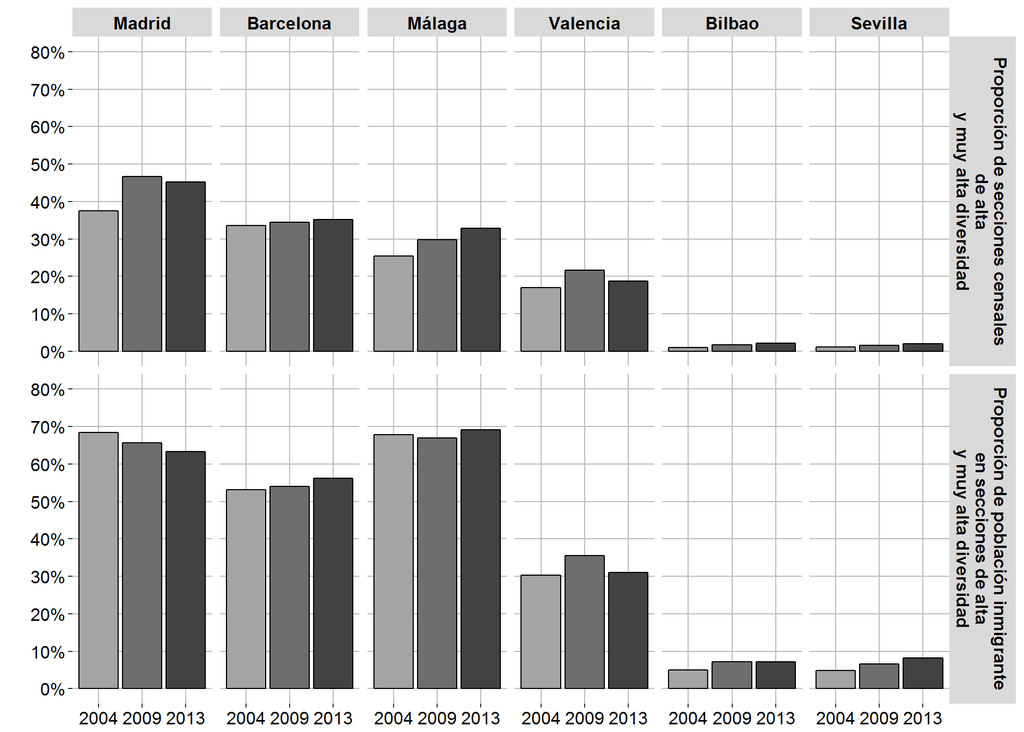

```r
library(ggplot2)
library(scales)

CAP2_GRAFIC2 <- read.csv("C:/Users/jgaleano/Desktop/ICARIA/CAP_2_GRAFIC2.csv", stringsAsFactors=FALSE)


CAP2_GRAFIC2$RMB <- factor(CAP2_GRAFIC2$RMB, levels = c("Madrid", "Barcelona", "Málaga", "Valencia", "Bilbao", "Sevilla"))
CAP2_GRAFIC2$CAT <- factor(CAP2_GRAFIC2$CAT, levels = c("Proporción de secciones censales de alta y muy alta diversidad","Proporción de población inmigrante en secciones de alta y muy alta diversidad"))

levels(CAP2_GRAFIC2$CAT)<- c("Proporción de secciones censales\nde alta\ny muy alta diversidad","Proporción de población inmigrante\nen secciones de alta\ny muy alta diversidad")

A<- ggplot(CAP2_GRAFIC2, aes(x = factor(YEAR), y = PROP, fill=factor(YEAR))) + geom_bar(stat = "identity",position = "dodge",colour="black")+#coord_flip()+
  facet_grid(CAT~RMB)+
  expand_limits(y=c(0,0.8))+
  scale_y_continuous(breaks=c(0,0.1,0.2,0.3,0.4,0.5,0.6,0.7,0.8),labels=percent)+

    scale_fill_manual(name="",
                     values=c("#A4A4A4", "#6E6E6E", "#424242"),
                     breaks=c("2004","2009","2013"),
                     labels=c("2004","2009","2013"))+
   theme(plot.title = element_text(lineheight=5.6, size=20, face="bold"),
              legend.title = element_blank(),
              legend.text = element_text(colour="black", size = 15),
                 legend.position = "none",
              legend.background = element_rect(fill=NA),
              #legend.justification=c(6,2),
              legend.direction = "horizontal",
              legend.key=element_rect(size=10),
              legend.key.size = unit(1.5, "lines"),

              axis.title.x = element_blank(),
              axis.text.x  = element_text(angle = 00,vjust=0.5, size=12,colour="black"),
              axis.title.y = element_text(colour="black", size=12),
              axis.text.y  = element_text(vjust=0.5, size=12,colour="black"),
              strip.text=element_text(angle = 0,vjust=0.5, size=12,colour="black", face = "bold"),
              panel.background = element_rect(fill = "#FFFFFF"),
              panel.grid = element_line(colour="#000000"),
              panel.grid.major=element_line(colour="#BDBDBD"),
              panel.grid.minor=element_line(colour="white"),
              plot.background = element_rect(fill = "#FFFFFF"))+
  ylab("")+ xlab("")
A
```

```r
setwd("C:\\Users\\jgaleano\\Desktop\\ICARIA\\GRAFICOS")
#ggsave("CAP2_FIG2.tiff", scale = 3, width = 9.8, height = 7, units = c("cm"), dpi = 300)
```

#### **Figura 2.3: Composición de la población metropolitana según la diversidad de la sección de residencia, 2014**

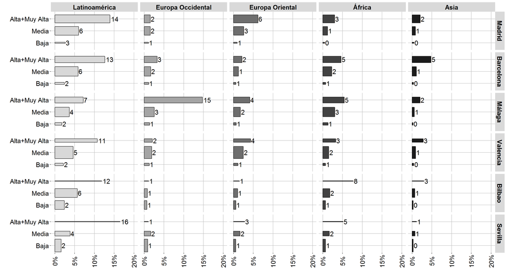

```r
library(ggplot2)
library(scales)

COMPIDVERSIDAD <- read.csv("C:/Users/jgaleano/Dropbox/CSVs/COMPDIVERSIDAD.csv", stringsAsFactors=FALSE)

COMPIDVERSIDAD$CATDIVERSITY2 <- factor(COMPIDVERSIDAD$CATDIVERSITY2 ,
                                levels = c("Baja", "Media", "Alta+Muy Alta"))

COMPIDVERSIDAD$CONT <- factor(COMPIDVERSIDAD$CONT ,
                                       levels = c("España", "Latinoamérica", "Europa Occidental",
                                                  "Europa Oriental", "África", "Asia"))

COMPIDVERSIDAD$AREA <- factor(COMPIDVERSIDAD$AREA ,
                       levels = c("Madrid","Barcelona",
                                  "Málaga",
                                  "Valencia",
                                  "Bilbao",
                                  "Sevilla"))

COMPIDVERSIDAD$secciones2 <- COMPIDVERSIDAD$secciones2 *1.5

COMPIDVERSIDAD<-COMPIDVERSIDAD[!COMPIDVERSIDAD$CONT=="España", ]

A<-ggplot(data=COMPIDVERSIDAD, aes(x=CATDIVERSITY2, y=PROP, fill=factor(CONT),width=secciones2,label=round(PROP*100, digits =0))) +
  geom_bar(stat="identity", position=position_dodge(), colour="black")+
  coord_flip()+
  geom_text(hjust=-0.15,size=5.5,position = position_dodge(width=1))+
  facet_grid(AREA~CONT)+
  scale_y_continuous(limits=c(0, .2),labels = percent, oob = rescale_none)+
  scale_fill_manual(name="",
                     values=c("#D8D8D8", "#A4A4A4", "#6E6E6E", "#424242", "#1C1C1C"),
                     breaks=c("Latinoamérica","Europa Occidental","Europa Oriental","África","Asia"),
                     labels=c("Latinoamérica","Europa Occidental","Europa Oriental","África","Asia"))+
  guides(fill = guide_legend(reverse=TRUE))+
   theme(plot.title = element_text(lineheight=5.6, size=20, face="bold"),
              legend.title = element_blank(),
              legend.text = element_text(colour="black", size = 15),
              legend.position="none",
              legend.background = element_rect(fill="#FFFFFF"),
              legend.justification=c(0,1),
              legend.key.size = unit(1, "cm"),
              axis.title.x = element_blank(),
              axis.text.x  = element_text(angle = 90,vjust=0.5, size=15,colour="black"),
              axis.title.y = element_text(colour="black", size=15),
              axis.text.y  = element_text(vjust=0.5, size=15,colour="black"),
              strip.text=element_text(angle = 0,vjust=0.5, size=15,colour="black", face = "bold"),
              panel.background = element_rect(fill = "#FFFFFF"),
              panel.grid = element_line(colour="#000000"),
              panel.grid.major=element_line(colour="#BDBDBD"),
              panel.grid.minor=element_line(colour="white"),
              plot.background = element_rect(fill = "#FFFFFF"))+xlab("")

A
```

```r
setwd("C:\\Users\\jgaleano\\Desktop\\ICARIA\\GRAFICOS")
#ggsave("CAP2_FIG3_POBLACION_SEGUN_DICERSIDAD_AREA_2014.tiff", scale = 3, width = 16.5, height = 8.8, units = c("cm"), dpi = 300)
```

#### **Figura 2.4: Distribución relativa de la población metropolitana según la diversidad de la sección de residencia, 2014**

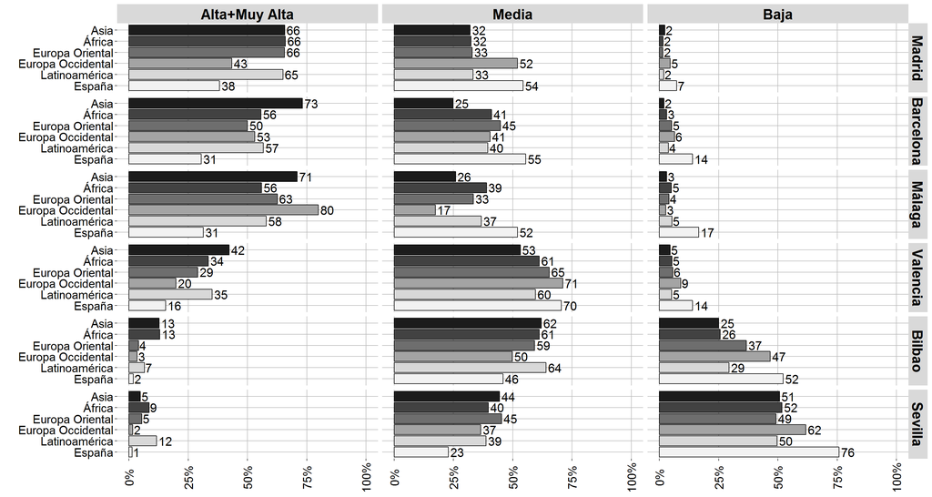

```r
library(scales)
COMPDIVERSIDAD <- read.csv("C:/Users/jgaleano/Dropbox/CSVs/DIVERSIDADAREAS2.csv", stringsAsFactors=FALSE)


COMPDIVERSIDAD$CATDIVERSITY2 <- factor(COMPDIVERSIDAD$CATDIVERSITY2 ,
                                       levels = c("Alta+Muy Alta", "Media", "Baja"))

COMPDIVERSIDAD$CONT <- factor(COMPDIVERSIDAD$CONT ,
                              levels = c("España", "Latinoamérica", "Europa Occidental",
                                         "Europa Oriental", "África", "Asia"))

COMPDIVERSIDAD$AREA <- factor(COMPDIVERSIDAD$AREA ,
                              levels = c("Madrid","Barcelona",
                                         "Málaga",
                                         "Valencia",
                                         "Bilbao",
                                         "Sevilla"))


A<-ggplot(data=COMPDIVERSIDAD, aes(x=CONT, y=PROP, fill=CONT,label=round(PROP*100, digits =0)))+
  geom_bar(stat="identity", colour="black")+
  scale_y_continuous(limits=c(0, 1),labels = percent)+
   geom_text(hjust=-0.15,size=5.5,position = position_dodge(width=1))+
  coord_flip()+
  facet_grid(AREA~CATDIVERSITY2)+
  scale_fill_manual(name="",
                     values=c("#F2F2F2", "#D8D8D8", "#A4A4A4", "#6E6E6E", "#424242", "#1C1C1C"),
                     breaks=c("España","Latinoamérica","Europa Occidental","Europa Oriental","África","Asia"),
                     labels=c("España","Latinoamérica","Europa Occidental","Europa Oriental","África","Asia"))+
    theme(plot.title = element_text(lineheight=5.6, size=20, face="bold"),
              legend.title = element_blank(),
              legend.text = element_text(colour="black", size = 15),
              legend.position="none",
              legend.background = element_rect(fill="#FFFFFF"),
              legend.justification=c(0,1),
              legend.key.size = unit(1, "cm"),
              axis.title.x = element_blank(),
              axis.text.x  = element_text(angle = 90,vjust=0.5, size=15,colour="black"),
              axis.title.y = element_text(colour="black", size=15),
              axis.text.y  = element_text(vjust=0.5, size=15,colour="black"),
              strip.text=element_text(angle = 0,vjust=0.5, size=18,colour="black", face = "bold"),
              panel.background = element_rect(fill = "#FFFFFF"),
              panel.grid = element_line(colour="#000000"),
              panel.grid.major=element_line(colour="#BDBDBD"),
              panel.grid.minor=element_line(colour="white"),
              plot.background = element_rect(fill = "#FFFFFF"))+
  ylab("")+ xlab("")
A
```

```r
setwd("C:\\Users\\jgaleano\\Desktop\\ICARIA\\GRAFICOS")
#ggsave("CAP2_FIG4_POBLACION_EN_DICERSIDAD_AREA_2014.tiff", scale = 3, width = 16.5, height = 8.8, units = c("cm"), dpi = 300)
```

#### **Figura 2.5: Figura 5 Evolución de la diversidad en las regiones metropolitanas, 2000-2014.**

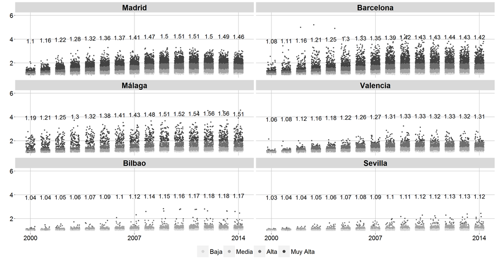

```r
load("C:\\Users\\jgaleano\\Desktop\\ICARIA\\DATOS_ICARIA_3.Rdata")

dffinal$AREA <- factor(dffinal$AREA ,
                   levels = c("Madrid","Barcelona",
                              "Málaga",
                              "Valencia",
                              "Bilbao",
                              "Sevilla"))

dffinal$CATDIVERSITY2 <- factor(dffinal$CATDIVERSITY2 ,
                   levels = c("Baja", "Media", "Alta", "Muy Alta"))


POP <- dffinal %>% group_by(AREA,YEAR) %>%  summarise(secciones = n(),
                                                 Spanish = sum(Spanish),
                                                 LatinaAmerica = sum(LatinAmerica),
                                                 WesternEurope = sum(WesternEurope),
                                                 EasternEurope = sum(EasternEurope),
                                                 Africa = sum(Africa),
                                                 Asia = sum(Asia),
                                                 Others = sum(Others),
                                                 Total_ext=sum(Total_ext),
                                                 Totalpop=sum(Totalpop))


POP$Totalpop2 <-with(POP, Totalpop-Others)

POP$DIVERSITY <- with(POP, (1/(((Spanish/Totalpop2)^2)+
                    ((LatinaAmerica/Totalpop2)^2)+
                    ((WesternEurope/Totalpop2)^2)+
                    ((EasternEurope/Totalpop2)^2)+
                    ((Africa/Totalpop2)^2)+
                    ((Asia/Totalpop2)^2))))


p <- ggplot(dffinal, aes(YEAR, DIVERSITY))
A<- p + geom_jitter(aes(colour = CATDIVERSITY2),width = .75,size=1)+
  scale_y_continuous(limits = c(1, 6))+
  facet_wrap( ~ AREA, ncol=2)+
  scale_x_continuous(breaks=seq(2000,2014, 7))+
  scale_colour_manual(name="",
                      values=c("#D8D8D8", "#A4A4A4", "#6E6E6E","#424242"),
                      breaks=c("Baja", "Media", "Alta","Muy Alta"),
                      labels=c("Baja", "Media", "Alta","Muy Alta"))+

  geom_text(data=POP, size=5,aes(x=YEAR, y= DIVERSITY+2.75,
                                   label=paste(round(DIVERSITY, 2),sep="" ),
                                   inherit.aes=FALSE, parse=FALSE))+

    theme(plot.title = element_text(lineheight=5.6, size=20, face="bold"),
              legend.title = element_blank(),
              legend.text = element_text(colour="black", size = 15),
              legend.position="bottom",
              legend.background = element_rect(fill="#FFFFFF"),
              legend.justification=c(0,1),
              legend.key.size = unit(1, "cm"),
              axis.title.x = element_blank(),
              axis.text.x  = element_text(angle = 00,vjust=0.5, size=15,colour="black"),
              axis.title.y = element_text(colour="black", size=15),
              axis.text.y  = element_text(vjust=0.5, size=15,colour="black"),
              strip.text=element_text(angle = 0,vjust=0.5, size=18,colour="black", face = "bold"),
              panel.background = element_rect(fill = "#FFFFFF"),
              panel.grid = element_line(colour="#000000"),
              panel.grid.major=element_line(colour="#BDBDBD"),
              panel.grid.minor=element_line(colour="white"),
              plot.background = element_rect(fill = "#FFFFFF"))+
  guides(colour = guide_legend(override.aes = list(size=3)))+
  ylab("")+ xlab("")
A
```

```r
setwd("C:\\Users\\jgaleano\\Desktop\\ICARIA\\GRAFICOS")
#ggsave("CAP2_FIG5_DIVERSIDAD_SECCIONES_AREA_2000_2014.tiff", scale = 3, width = 16.5, height = 8.8, units = c("cm"), dpi = 300)
```

### **Capítulo 5: LA TENTACIÓN PIGMENTOCRÁTICA. FISURAS EN EL DISCURSO INTERCULTURAL [Autores: Andreu Domingo & Xiana Bueno]**

#### **Figura 5.1: Percepciones sobre la integración de los diferentes grupos de origen, Técnicos municipales de inmigración, Cataluña, Madrid y Andalucía, 2013**

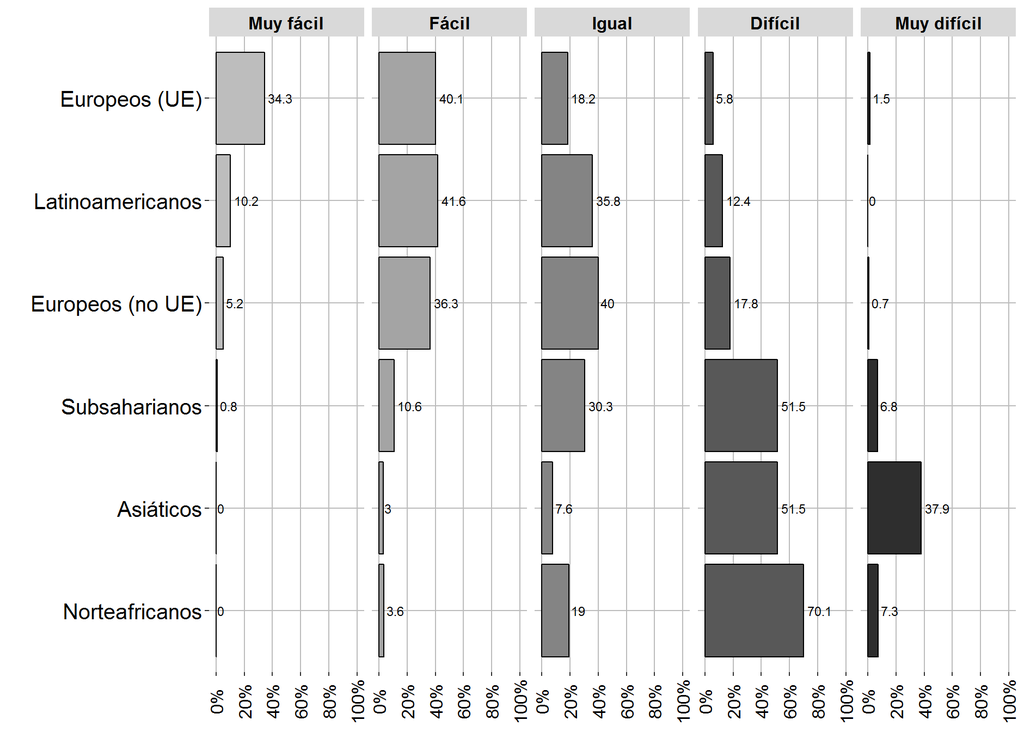

```r
library(ggplot2)
library(scales)
CAP5_GRAFIC1 <- read.csv("C:/Users/jgaleano/Desktop/ICARIA/CAP_5_GRAFIC1.csv", stringsAsFactors=FALSE)


CAP5_GRAFIC1$CAT <- factor(CAP5_GRAFIC1$CAT,  levels = c("Muy fácil","Fácil","Igual","Difícil","Muy difícil"))



CAP5_GRAFIC1$GROUP<-factor(CAP5_GRAFIC1$GROUP, levels=subset(CAP5_GRAFIC1, CAT  == "Muy fácil")[order(subset(CAP5_GRAFIC1, CAT  == "Muy fácil")$PROP),3])


A<- ggplot(data=CAP5_GRAFIC1, aes(x=GROUP, y=PROP, fill=CAT, label=round(PROP*100, digits =2))) + geom_bar(stat="identity",colour="black")+
  coord_flip()+geom_text(hjust=-0.15, size=3)+
 # scale_x_continuous(breaks=c(2001,2011))+
  scale_y_continuous(breaks=c(0,0.2,0.4,0.6,0.8,1),labels=percent)+
  expand_limits(y=c(0,1))+
  facet_wrap(~ CAT, nrow=1)+
  scale_fill_manual(name="",
                     values=rev(c("#2E2E2E", "#585858", "#848484", "#A4A4A4", "#BDBDBD")),
                     breaks=rev(c("Muy fácil","Fácil","Igual","Difícil","Muy difícil")),
                     labels=rev(c("Muy fácil","Fácil","Igual","Difícil","Muy difícil")))+
   theme(plot.title = element_text(lineheight=5.6, size=20, face="bold"),
              legend.title = element_blank(),
              legend.text = element_text(colour="black", size = 15),
              legend.position = "none",
              legend.background = element_rect(fill=NA),
              #legend.justification=c(6,2),
              #legend.direction = "vertical",
              #legend.key=element_rect(size=10),
              legend.key.size = unit(1.5, "lines"),

              axis.title.x = element_blank(),
              axis.text.x  = element_text(angle = 90,vjust=0.5, size=12,colour="black"),
              axis.title.y = element_text(colour="black", size=12),
              axis.text.y  = element_text(vjust=0.5, size=15,colour="black"),
              strip.text=element_text(angle = 0,vjust=0.5, size=12,colour="black", face = "bold"),
              panel.background = element_rect(fill = "#FFFFFF"),
              panel.grid = element_line(colour="#000000"),
              panel.grid.major=element_line(colour="#BDBDBD"),
              panel.grid.minor=element_line(colour="white"),
              plot.background = element_rect(fill = "#FFFFFF"))+
  ylab("")+ xlab("")
A
```

```r
setwd("C:\\Users\\jgaleano\\Desktop\\ICARIA\\GRAFICOS")
#ggsave("CAP5_FIG1.tiff", scale = 3, width = 9.8, height = 7, units = c("cm"), dpi = 300)
```

### **Capítulo 6: INMIGRACIÓN INTERNACIONAL Y DIVERSIFICACIÓN DE LOS HOGARES [Autores: Rocío Treviño & Pau Miret Gamundi]**

#### **Figura 6.1: Distribución de los hogares y de la población por tipo de hogar, población nacida en España y población nacida en el extranjero, 2011**

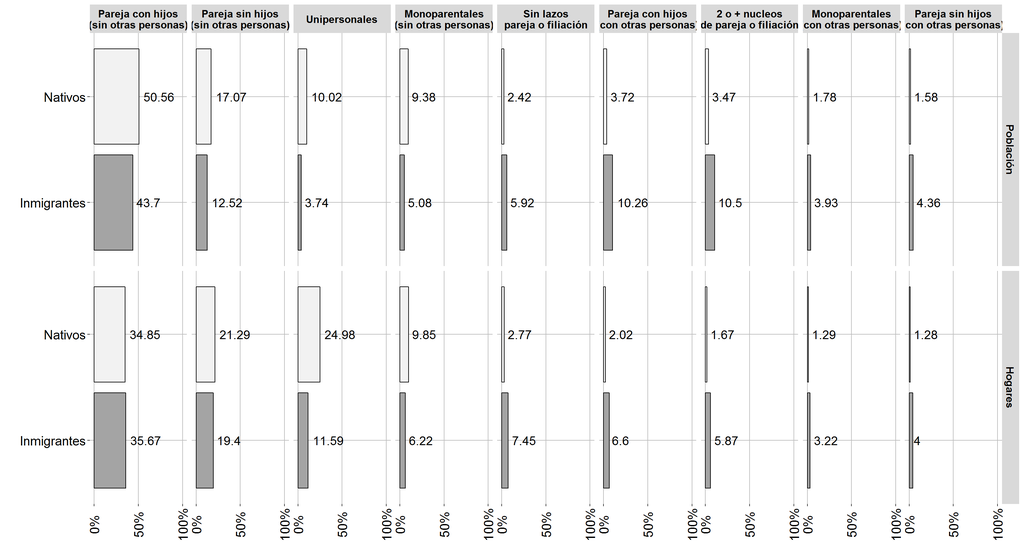

```r
CAP6_GRAFIC1 <- read.csv("C:/Users/jgaleano/Desktop/ICARIA/CAP_6_GRAFIC1.csv", stringsAsFactors=FALSE)

CAP6_GRAFIC1$HOGAR2 <- rep(c("Unipersonales", "Pareja sin hijos\n(sin otras personas)","Pareja con hijos\n(sin otras personas)",
                          "Monoparentales\n(sin otras personas)", "Pareja sin hijos\n(con otras personas)",
                          "Pareja con hijos\n(con otras personas)","Monoparentales\n(con otras personas)",
                          "2 o + nucleos\nde pareja o filiación", "Sin lazos\npareja o filiación"),4)


CAP6_GRAFIC1$HOGAR2 <- factor(CAP6_GRAFIC1$HOGAR2,
                   levels = c("Pareja con hijos\n(sin otras personas)","Pareja sin hijos\n(sin otras personas)",
                              "Unipersonales","Monoparentales\n(sin otras personas)","Sin lazos\npareja o filiación",
                              "Pareja con hijos\n(con otras personas)","2 o + nucleos\nde pareja o filiación",
                              "Monoparentales\n(con otras personas)","Pareja sin hijos\n(con otras personas)"))


CAP6_GRAFIC1$TIPO <- factor(CAP6_GRAFIC1$TIPO,
                   levels = c("Población","Hogares"))

A<-ggplot(data=CAP6_GRAFIC1, aes(x=POP, y=PROP, fill=POP, label=round(PROP*100, digits =2))) +
  geom_bar(stat="identity",colour="black")+
  coord_flip()+
  geom_text(hjust=-0.15, size=5)+
  scale_y_continuous(breaks=c(0,0.5,1),labels=percent)+
  expand_limits(y=c(0,1))+
  facet_grid(TIPO~  HOGAR2)+
    scale_fill_manual(name="",
                     values=c( "#A4A4A4","#F2F2F2"), #"#D8D8D8","#6E6E6E", "#424242", "#1C1C1C"),
                     breaks=c("Nativos","Inmigrantes"),
                     labels=c("Nativos","Inmigrantes"))+
      theme(plot.title = element_text(lineheight=5.6, size=20, face="bold"),
              legend.title = element_blank(),
              legend.text = element_text(colour="black", size = 15),
              legend.position="none",
              legend.background = element_rect(fill="#FFFFFF"),
              legend.justification=c(0,1),
              legend.key.size = unit(1, "cm"),
              axis.title.x = element_blank(),
              axis.text.x  = element_text(angle = 90,vjust=0.5, size=15,colour="black"),
              axis.title.y = element_text(colour="black", size=15),
              axis.text.y  = element_text(vjust=0.5, size=15,colour="black"),
              strip.text=element_text(angle = 0,vjust=0.5, size=12,colour="black", face = "bold"),
              panel.background = element_rect(fill = "#FFFFFF"),
              panel.grid = element_line(colour="#000000"),
              panel.grid.major=element_line(colour="#BDBDBD"),
              panel.grid.minor=element_line(colour="white"),
              plot.background = element_rect(fill = "#FFFFFF"))+
  ylab("")+ xlab("")
A
```

```r
setwd("C:\\Users\\jgaleano\\Desktop\\ICARIA\\GRAFICOS")
#ggsave("CAP6_FIG1_HOGARES_2011.tiff", scale = 3, width = 16.5, height = 8.8, units = c("cm"), dpi = 300)
```

#### **Figura 6.2: Distribución de los hogares y de la población por tipo según estatus migratorio del hogar. 2011**

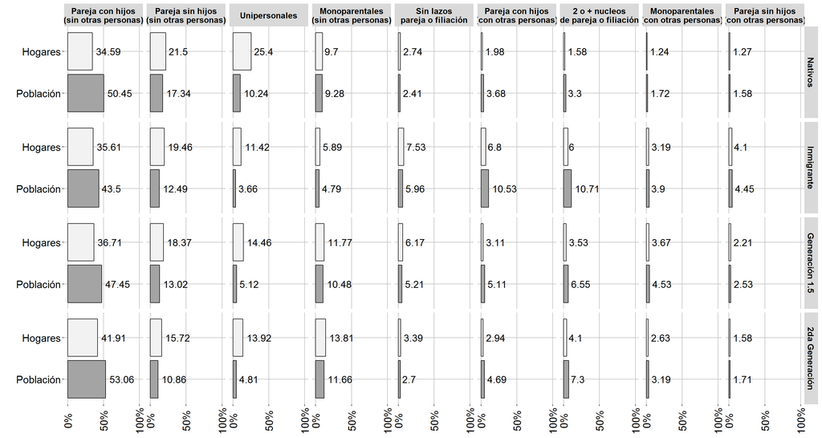

```r
CAP6_GRAFIC2 <- read.csv("C:/Users/jgaleano/Desktop/ICARIA/CAP_6_GRAFIC2.csv", stringsAsFactors=FALSE)

CAP6_GRAFIC2$HOGAR2 <- rep(c("Unipersonales", "Pareja sin hijos\n(sin otras personas)","Pareja con hijos\n(sin otras personas)",
                          "Monoparentales\n(sin otras personas)", "Pareja sin hijos\n(con otras personas)",
                          "Pareja con hijos\n(con otras personas)","Monoparentales\n(con otras personas)",
                          "2 o + nucleos\nde pareja o filiación", "Sin lazos\npareja o filiación"),4)


CAP6_GRAFIC2$HOGAR2 <- factor(CAP6_GRAFIC2$HOGAR2,
                   levels = c("Pareja con hijos\n(sin otras personas)","Pareja sin hijos\n(sin otras personas)",
                              "Unipersonales","Monoparentales\n(sin otras personas)","Sin lazos\npareja o filiación",
                              "Pareja con hijos\n(con otras personas)","2 o + nucleos\nde pareja o filiación",
                              "Monoparentales\n(con otras personas)","Pareja sin hijos\n(con otras personas)"))


CAP6_GRAFIC2$TIPO <- factor(CAP6_GRAFIC2$TIPO,
                   levels = c("Población","Hogares"))

CAP6_GRAFIC2$GRUPO <- factor(CAP6_GRAFIC2$GRUPO,
                   levels = c("Nativos","Inmigrante", "Generación 1.5", "2da Generación"))

A<-ggplot(data=CAP6_GRAFIC2, aes(x=TIPO, y=PROP, fill=TIPO, label=round(PROP*100, digits =2))) +
  geom_bar(stat="identity",colour="black")+
  coord_flip()+
  geom_text(hjust=-0.15, size=5)+
  scale_y_continuous(breaks=c(0,0.5,1),labels=percent)+
  expand_limits(y=c(0,1))+
  facet_grid(GRUPO~  HOGAR2)+
    scale_fill_manual(name="",
                     values=c( "#A4A4A4","#F2F2F2"), #"#D8D8D8","#6E6E6E", "#424242", "#1C1C1C"),
                     breaks=c("Hogares","Población"),
                     labels=c("Hogares","Población"))+
      theme(plot.title = element_text(lineheight=5.6, size=20, face="bold"),
              legend.title = element_blank(),
              legend.text = element_text(colour="black", size = 15),
              legend.position="none",
              legend.background = element_rect(fill="#FFFFFF"),
              legend.justification=c(0,1),
              legend.key.size = unit(1, "cm"),
              axis.title.x = element_blank(),
              axis.text.x  = element_text(angle = 90,vjust=0.5, size=15,colour="black"),
              axis.title.y = element_text(colour="black", size=15),
              axis.text.y  = element_text(vjust=0.5, size=15,colour="black"),
              strip.text=element_text(angle = 0,vjust=0.5, size=12,colour="black", face = "bold"),
              panel.background = element_rect(fill = "#FFFFFF"),
              panel.grid = element_line(colour="#000000"),
              panel.grid.major=element_line(colour="#BDBDBD"),
              panel.grid.minor=element_line(colour="white"),
              plot.background = element_rect(fill = "#FFFFFF"))+
  ylab("")+ xlab("")

A
```

```r
setwd("C:\\Users\\jgaleano\\Desktop\\ICARIA\\GRAFICOS")
#ggsave("CAP6_FIG2_HOGARES_2011.tiff", scale = 3, width = 16.5, height = 8.8, units = c("cm"), dpi = 300)
```

#### **Figura 6.3: Peso de los hogares complejos en el total según el estatus del hogar y el tipo de complejidad del hogar. 2011**

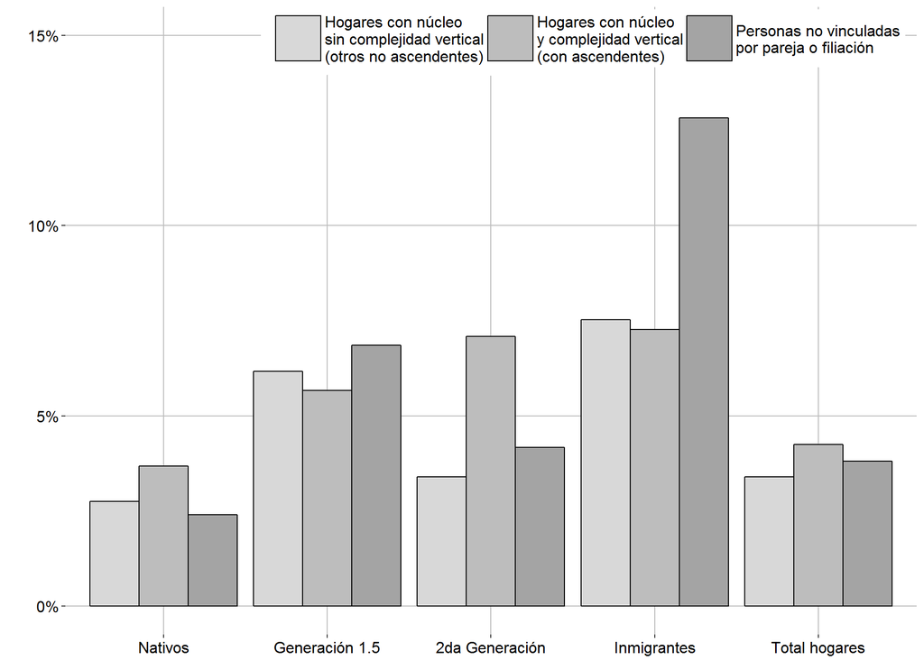

```r
CAP6_GRAFIC3 <- read.csv("C:/Users/jgaleano/Desktop/ICARIA/CAP_6_GRAFIC3.csv", stringsAsFactors=FALSE)

CAP6_GRAFIC3$HOGAR2 <- rep(c("Hogares con núcleo\nsin complejidad vertical\n(otros no ascendentes)","Hogares con núcleo\ny complejidad vertical\n(con ascendentes)","Personas no vinculadas\npor pareja o filiación"),5)

CAP6_GRAFIC3$POP <- factor(CAP6_GRAFIC3$POP,
                   levels = c("Nativos","Generación 1.5", "2da Generación", "Inmigrantes", "Total hogares"))

A<- ggplot(data=CAP6_GRAFIC3, aes(x=POP, y=PROP, fill=HOGAR2,label=round(PROP*100, digits =2))) +
   geom_bar(stat="identity", position=position_dodge(),colour="black")+
    #geom_text(hjust=-0.15, size=5)+
        scale_y_continuous(labels=percent)+
        expand_limits(y=c(0,0.15))+
        scale_fill_manual(values=c("#D8D8D8", "#BDBDBD", "#A4A4A4"),
                          breaks=c("Hogares con núcleo\nsin complejidad vertical\n(otros no ascendentes)","Hogares con núcleo\ny complejidad vertical\n(con ascendentes)","Personas no vinculadas\npor pareja o filiación"),
                          labels=c("Hogares con núcleo\nsin complejidad vertical\n(otros no ascendentes)","Hogares con núcleo\ny complejidad vertical\n(con ascendentes)","Personas no vinculadas\npor pareja o filiación"))+
         theme(plot.title = element_text(lineheight=5.6, size=20, face="bold"),
              legend.title = element_blank(),
              legend.text = element_text(colour="black", size = 12),
              legend.position = c(.61, .95),
              legend.background = element_rect(fill="#FFFFFF"),
              #legend.justification=c(6,2),
              legend.direction = "horizontal",
              legend.key=element_rect(size=10),
              legend.key.size = unit(2.5, "lines"),

              axis.title.x = element_blank(),
              axis.text.x  = element_text(angle = 00,vjust=0.5, size=12,colour="black"),
              axis.title.y = element_text(colour="black", size=12),
              axis.text.y  = element_text(vjust=0.5, size=12,colour="black"),
              strip.text=element_text(angle = 0,vjust=0.5, size=13,colour="black", face = "bold"),
              panel.background = element_rect(fill = "#FFFFFF"),
              panel.grid = element_line(colour="#000000"),
              panel.grid.major=element_line(colour="#BDBDBD"),
              panel.grid.minor=element_line(colour="white"),
              plot.background = element_rect(fill = "#FFFFFF"))+
  ylab("")+ xlab("")
A
```

```r
setwd("C:\\Users\\jgaleano\\Desktop\\ICARIA\\GRAFICOS")
#ggsave("CAP6_FIG3_HOGARES_2011.tiff", scale = 3, width = 9.8, height = 7, units = c("cm"), dpi = 300)
```

#### **Figura 6.4: Pirámides por origen del hogar y estructura familiar, 2011 (Marruecos)**

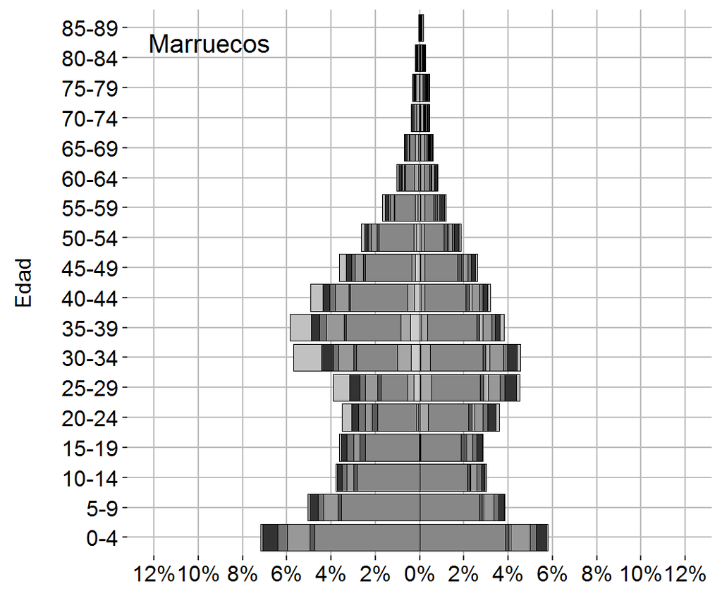

```r
CAP6_GRAFIC4 <- read.csv("C:/Users/jgaleano/Desktop/ICARIA/CAP_6_GRAFIC4_MARRUECOS.csv", stringsAsFactors=FALSE)

CAP6_GRAFIC4$EDAD <- factor(CAP6_GRAFIC4$EDAD,
                   levels = c("0-4","5-9","10-14","15-19","20-24","25-29","30-34","35-39","40-44","45-49",
                              "50-54","55-59","60-64","65-69","70-74","75-79","80-84","85-89"))


A<-ggplot(CAP6_GRAFIC4, aes(x=factor(EDAD), y=PROP, fill=HOGARES))+
  geom_bar(data = CAP6_GRAFIC4[(CAP6_GRAFIC4$SEX2=="Pareja con hijos Mujeres"|
                                         CAP6_GRAFIC4$SEX2=="Pareja con hijos y otros Mujeres"|
                                         CAP6_GRAFIC4$SEX2=="Personas no vinculadas por pareja o filiación Mujeres"|
                                         CAP6_GRAFIC4$SEX2=="Dos o más nucleos de pareja o filiación Mujeres"|
                                         CAP6_GRAFIC4$SEX2=="Monoparentales y otros Mujeres"|
                                         CAP6_GRAFIC4$SEX2=="Pareja sin hijos Mujeres"|
                                         CAP6_GRAFIC4$SEX2=="Pareja sin hijos y otros Mujeres"|
                                         CAP6_GRAFIC4$SEX2=="Unipersonales Mujeres"|
                                         CAP6_GRAFIC4$SEX2=="Monoparentales Mujeres"),],
           colour = I("Black"),stat="identity", size=.3, colour="black",
           aes(x = EDAD, y = PROP,fill = HOGARES), alpha = 1)+
  geom_bar(data = CAP6_GRAFIC4[(CAP6_GRAFIC4$SEX2=="Pareja con hijos Hombres"|
                                           CAP6_GRAFIC4$SEX2=="Pareja con hijos y otros Hombres"|
                                           CAP6_GRAFIC4$SEX2=="Personas no vinculadas por pareja o filiación Hombres"|
                                           CAP6_GRAFIC4$SEX2=="Dos o más nucleos de pareja o filiación Hombres"|
                                           CAP6_GRAFIC4$SEX2=="Monoparentales y otros Hombres"|
                                           CAP6_GRAFIC4$SEX2=="Pareja sin hijos Hombres"|
                                           CAP6_GRAFIC4$SEX2=="Pareja sin hijos y otros Hombre"|
                                           CAP6_GRAFIC4$SEX2=="Unipersonales Hombres"|
                                           CAP6_GRAFIC4$SEX2=="Monoparentales Hombres"),],
           colour = I("Black"),stat="identity", size=.3, colour="black",
           aes(x = EDAD, y = PROP,fill = HOGARES), alpha = 1)+
  coord_flip()+
scale_y_continuous(limits=c(-12,12),breaks = c(-12, -10, -8, -6, -4, -2,0, 2, 4, 6, 8, 10, 12),
                     labels = paste0(as.character(c(seq(12, 0, -2), seq(2, 12, 2))), "%")) +
   scale_fill_grey()+

  annotate("text", x = 17.5, y = -9.5, label = "Marruecos",size=5)+

 theme(plot.title = element_text(lineheight=5.6, size=10, face="bold"),
              legend.title = element_blank(),
              legend.text = element_text(colour="black", size = 12),
              legend.position="none",
              legend.background = element_rect(fill="#FFFFFF"),
              legend.justification=c(0,1),
              legend.key.size = unit(1, "cm"),
              axis.title.x = element_blank(),
              axis.text.x  = element_text(angle = 0,vjust=0.5, size=12,colour="black"),
              axis.title.y = element_text(colour="black", size=12),
              axis.text.y  = element_text(vjust=0.5, size=12,colour="black"),
              strip.text=element_text(angle = 0,vjust=0.5, size=9,colour="black", face = "bold"),
              panel.background = element_rect(fill = "#FFFFFF"),
              panel.grid = element_line(colour="#000000"),
              panel.grid.major=element_line(colour="#BDBDBD"),
              panel.grid.minor=element_line(colour="white"),
              plot.background = element_rect(fill = "#FFFFFF"))+
  xlab("Edad\n")
A
```

```r
setwd("C:\\Users\\jgaleano\\Desktop\\ICARIA\\GRAFICOS")
#ggsave("CAP6_FIG4_PIRAMIDE_MARRUECOS.tiff", scale = 3, width = 5.5, height = 4.1, units = c("cm"), dpi = 300)
```

#### **Figura 6.4: Pirámides por origen del hogar y estructura familiar, 2011 (Rumania)**

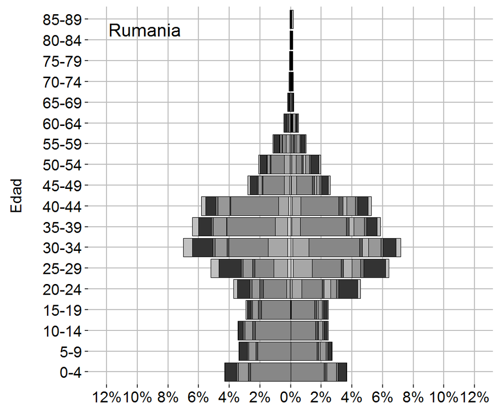

```r
library(ggplot2)
CAP6_GRAFIC4 <- read.csv("C:/Users/jgaleano/Desktop/ICARIA/CAP_6_GRAFIC4_RUMANIA.csv", stringsAsFactors=FALSE)

CAP6_GRAFIC4$EDAD <- factor(CAP6_GRAFIC4$EDAD,
                   levels = c("0-4","5-9","10-14","15-19","20-24","25-29","30-34","35-39","40-44","45-49",
                              "50-54","55-59","60-64","65-69","70-74","75-79","80-84","85-89"))


A<-ggplot(CAP6_GRAFIC4, aes(x=factor(EDAD), y=PROP, fill=HOGARES))+
  geom_bar(data = CAP6_GRAFIC4[(CAP6_GRAFIC4$SEX2=="Pareja con hijos Mujeres"|
                                         CAP6_GRAFIC4$SEX2=="Pareja con hijos y otros Mujeres"|
                                         CAP6_GRAFIC4$SEX2=="Personas no vinculadas por pareja o filiación Mujeres"|
                                         CAP6_GRAFIC4$SEX2=="Dos o más nucleos de pareja o filiación Mujeres"|
                                         CAP6_GRAFIC4$SEX2=="Monoparentales y otros Mujeres"|
                                         CAP6_GRAFIC4$SEX2=="Pareja sin hijos Mujeres"|
                                         CAP6_GRAFIC4$SEX2=="Pareja sin hijos y otros Mujeres"|
                                         CAP6_GRAFIC4$SEX2=="Unipersonales Mujeres"|
                                         CAP6_GRAFIC4$SEX2=="Monoparentales Mujeres"),],
           colour = I("Black"),stat="identity", size=.3, colour="black",
           aes(x = EDAD, y = PROP,fill = HOGARES), alpha = 1)+
  geom_bar(data = CAP6_GRAFIC4[(CAP6_GRAFIC4$SEX2=="Pareja con hijos Hombres"|
                                           CAP6_GRAFIC4$SEX2=="Pareja con hijos y otros Hombres"|
                                           CAP6_GRAFIC4$SEX2=="Personas no vinculadas por pareja o filiación Hombres"|
                                           CAP6_GRAFIC4$SEX2=="Dos o más nucleos de pareja o filiación Hombres"|
                                           CAP6_GRAFIC4$SEX2=="Monoparentales y otros Hombres"|
                                           CAP6_GRAFIC4$SEX2=="Pareja sin hijos Hombres"|
                                           CAP6_GRAFIC4$SEX2=="Pareja sin hijos y otros Hombre"|
                                           CAP6_GRAFIC4$SEX2=="Unipersonales Hombres"|
                                           CAP6_GRAFIC4$SEX2=="Monoparentales Hombres"),],
           colour = I("Black"),stat="identity", size=.3, colour="black",
           aes(x = EDAD, y = PROP,fill = HOGARES), alpha = 1)+
  coord_flip()+
scale_y_continuous(limits=c(-12,12),breaks = c(-12, -10, -8, -6, -4, -2,0, 2, 4, 6, 8, 10, 12),
                     labels = paste0(as.character(c(seq(12, 0, -2), seq(2, 12, 2))), "%")) +
   scale_fill_grey()+

  annotate("text", x = 17.5, y = -9.5, label = "Rumania",size=5)+

 theme(plot.title = element_text(lineheight=5.6, size=10, face="bold"),
              legend.title = element_blank(),
              legend.text = element_text(colour="black", size = 12),
              legend.position="none",
              legend.background = element_rect(fill="#FFFFFF"),
              legend.justification=c(0,1),
              legend.key.size = unit(1, "cm"),
              axis.title.x = element_blank(),
              axis.text.x  = element_text(angle = 0,vjust=0.5, size=12,colour="black"),
              axis.title.y = element_text(colour="black", size=12),
              axis.text.y  = element_text(vjust=0.5, size=12,colour="black"),
              strip.text=element_text(angle = 0,vjust=0.5, size=9,colour="black", face = "bold"),
              panel.background = element_rect(fill = "#FFFFFF"),
              panel.grid = element_line(colour="#000000"),
              panel.grid.major=element_line(colour="#BDBDBD"),
              panel.grid.minor=element_line(colour="white"),
              plot.background = element_rect(fill = "#FFFFFF"))+
  xlab("Edad\n")
A
```

```r
setwd("C:\\Users\\jgaleano\\Desktop\\ICARIA\\GRAFICOS")
#ggsave("CAP6_FIG4_PIRAMIDE_RUMANIA.tiff", scale = 3, width = 6.3, height = 4.7, units = c("cm"), dpi = 300)
```

#### **Figura 6.4: Pirámides por origen del hogar y estructura familiar, 2011 (ECUADOR)**

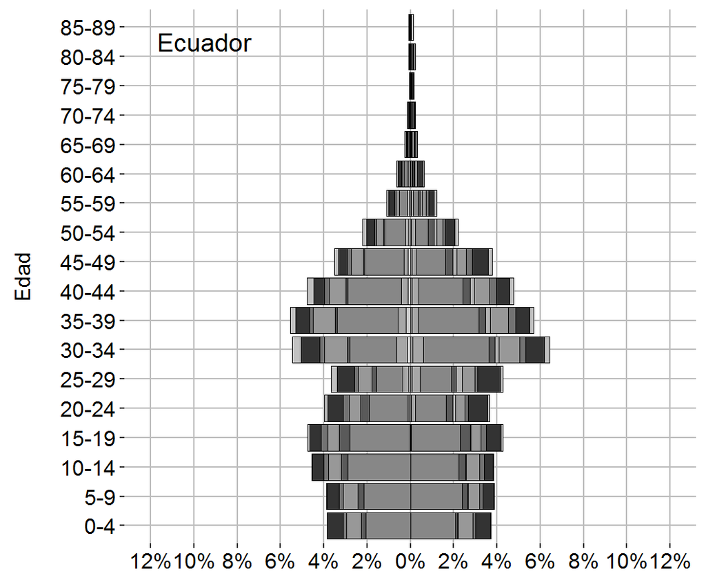

```r
library(ggplot2)
CAP6_GRAFIC4 <- read.csv("C:/Users/jgaleano/Desktop/ICARIA/CAP_6_GRAFIC4_ECUADOR.csv", stringsAsFactors=FALSE)

CAP6_GRAFIC4$EDAD <- factor(CAP6_GRAFIC4$EDAD,
                   levels = c("0-4","5-9","10-14","15-19","20-24","25-29","30-34","35-39","40-44","45-49",
                              "50-54","55-59","60-64","65-69","70-74","75-79","80-84","85-89"))


A<-ggplot(CAP6_GRAFIC4, aes(x=factor(EDAD), y=PROP, fill=HOGARES))+
  geom_bar(data = CAP6_GRAFIC4[(CAP6_GRAFIC4$SEX2=="Pareja con hijos Mujeres"|
                                         CAP6_GRAFIC4$SEX2=="Pareja con hijos y otros Mujeres"|
                                         CAP6_GRAFIC4$SEX2=="Personas no vinculadas por pareja o filiación Mujeres"|
                                         CAP6_GRAFIC4$SEX2=="Dos o más nucleos de pareja o filiación Mujeres"|
                                         CAP6_GRAFIC4$SEX2=="Monoparentales y otros Mujeres"|
                                         CAP6_GRAFIC4$SEX2=="Pareja sin hijos Mujeres"|
                                         CAP6_GRAFIC4$SEX2=="Pareja sin hijos y otros Mujeres"|
                                         CAP6_GRAFIC4$SEX2=="Unipersonales Mujeres"|
                                         CAP6_GRAFIC4$SEX2=="Monoparentales Mujeres"),],
           colour = I("Black"),stat="identity", size=.3, colour="black",
           aes(x = EDAD, y = PROP,fill = HOGARES), alpha = 1)+
  geom_bar(data = CAP6_GRAFIC4[(CAP6_GRAFIC4$SEX2=="Pareja con hijos Hombres"|
                                           CAP6_GRAFIC4$SEX2=="Pareja con hijos y otros Hombres"|
                                           CAP6_GRAFIC4$SEX2=="Personas no vinculadas por pareja o filiación Hombres"|
                                           CAP6_GRAFIC4$SEX2=="Dos o más nucleos de pareja o filiación Hombres"|
                                           CAP6_GRAFIC4$SEX2=="Monoparentales y otros Hombres"|
                                           CAP6_GRAFIC4$SEX2=="Pareja sin hijos Hombres"|
                                           CAP6_GRAFIC4$SEX2=="Pareja sin hijos y otros Hombre"|
                                           CAP6_GRAFIC4$SEX2=="Unipersonales Hombres"|
                                           CAP6_GRAFIC4$SEX2=="Monoparentales Hombres"),],
           colour = I("Black"),stat="identity", size=.3, colour="black",
           aes(x = EDAD, y = PROP,fill = HOGARES), alpha = 1)+
  coord_flip()+
scale_y_continuous(limits=c(-12,12),breaks = c(-12, -10, -8, -6, -4, -2,0, 2, 4, 6, 8, 10, 12),
                     labels = paste0(as.character(c(seq(12, 0, -2), seq(2, 12, 2))), "%")) +
   scale_fill_grey()+

  annotate("text", x = 17.5, y = -9.5, label = "Ecuador",size=5)+

 theme(plot.title = element_text(lineheight=5.6, size=10, face="bold"),
              legend.title = element_blank(),
              legend.text = element_text(colour="black", size = 12),
              legend.position="none",
              legend.background = element_rect(fill="#FFFFFF"),
              legend.justification=c(0,1),
              legend.key.size = unit(1, "cm"),
              axis.title.x = element_blank(),
              axis.text.x  = element_text(angle = 0,vjust=0.5, size=12,colour="black"),
              axis.title.y = element_text(colour="black", size=12),
              axis.text.y  = element_text(vjust=0.5, size=12,colour="black"),
              strip.text=element_text(angle = 0,vjust=0.5, size=9,colour="black", face = "bold"),
              panel.background = element_rect(fill = "#FFFFFF"),
              panel.grid = element_line(colour="#000000"),
              panel.grid.major=element_line(colour="#BDBDBD"),
              panel.grid.minor=element_line(colour="white"),
              plot.background = element_rect(fill = "#FFFFFF"))+
  xlab("Edad\n")
A
```

```r
setwd("C:\\Users\\jgaleano\\Desktop\\ICARIA\\GRAFICOS")
#ggsave("CAP6_FIG4_PIRAMIDE_ECUADOR.tiff", scale = 3, width = 5.5, height = 4.1, units = c("cm"), dpi = 300)
```

#### **Figura 6.4: Pirámides por origen del hogar y estructura familiar, 2011 (FRANCIA)**

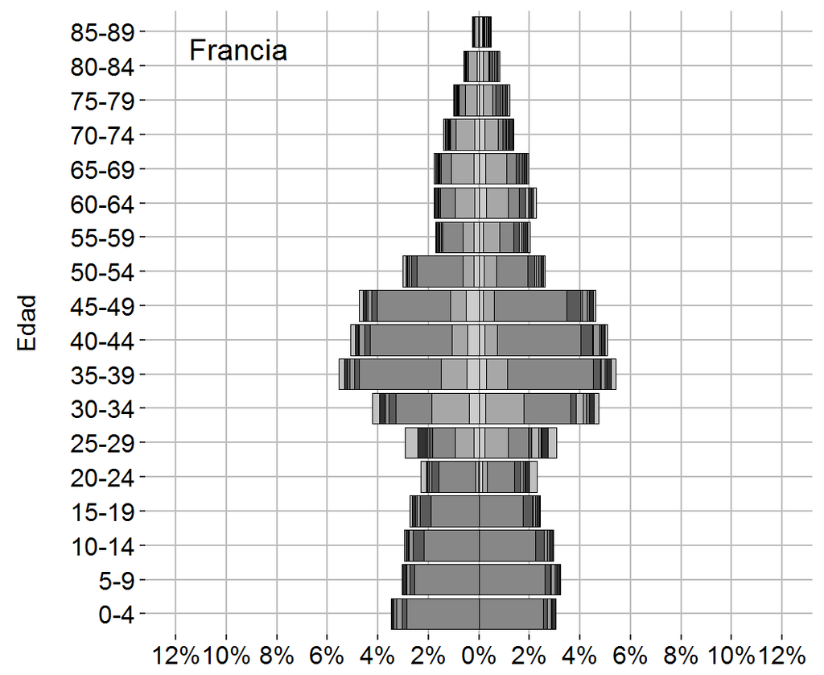

```r
library(ggplot2)
CAP6_GRAFIC4 <- read.csv("C:/Users/jgaleano/Desktop/ICARIA/CAP_6_GRAFIC4_FRANCIA.csv", stringsAsFactors=FALSE)

CAP6_GRAFIC4$EDAD <- factor(CAP6_GRAFIC4$EDAD,
                   levels = c("0-4","5-9","10-14","15-19","20-24","25-29","30-34","35-39","40-44","45-49",
                              "50-54","55-59","60-64","65-69","70-74","75-79","80-84","85-89"))


A<-ggplot(CAP6_GRAFIC4, aes(x=factor(EDAD), y=PROP, fill=HOGARES))+
  geom_bar(data = CAP6_GRAFIC4[(CAP6_GRAFIC4$SEX2=="Pareja con hijos Mujeres"|
                                         CAP6_GRAFIC4$SEX2=="Pareja con hijos y otros Mujeres"|
                                         CAP6_GRAFIC4$SEX2=="Personas no vinculadas por pareja o filiación Mujeres"|
                                         CAP6_GRAFIC4$SEX2=="Dos o más nucleos de pareja o filiación Mujeres"|
                                         CAP6_GRAFIC4$SEX2=="Monoparentales y otros Mujeres"|
                                         CAP6_GRAFIC4$SEX2=="Pareja sin hijos Mujeres"|
                                         CAP6_GRAFIC4$SEX2=="Pareja sin hijos y otros Mujeres"|
                                         CAP6_GRAFIC4$SEX2=="Unipersonales Mujeres"|
                                         CAP6_GRAFIC4$SEX2=="Monoparentales Mujeres"),],
           colour = I("Black"),stat="identity", size=.3, colour="black",
           aes(x = EDAD, y = PROP,fill = HOGARES), alpha = 1)+
  geom_bar(data = CAP6_GRAFIC4[(CAP6_GRAFIC4$SEX2=="Pareja con hijos Hombres"|
                                           CAP6_GRAFIC4$SEX2=="Pareja con hijos y otros Hombres"|
                                           CAP6_GRAFIC4$SEX2=="Personas no vinculadas por pareja o filiación Hombres"|
                                           CAP6_GRAFIC4$SEX2=="Dos o más nucleos de pareja o filiación Hombres"|
                                           CAP6_GRAFIC4$SEX2=="Monoparentales y otros Hombres"|
                                           CAP6_GRAFIC4$SEX2=="Pareja sin hijos Hombres"|
                                           CAP6_GRAFIC4$SEX2=="Pareja sin hijos y otros Hombre"|
                                           CAP6_GRAFIC4$SEX2=="Unipersonales Hombres"|
                                           CAP6_GRAFIC4$SEX2=="Monoparentales Hombres"),],
           colour = I("Black"),stat="identity", size=.3, colour="black",
           aes(x = EDAD, y = PROP,fill = HOGARES), alpha = 1)+
  coord_flip()+
scale_y_continuous(limits=c(-12,12),breaks = c(-12, -10, -8, -6, -4, -2,0, 2, 4, 6, 8, 10, 12),
                     labels = paste0(as.character(c(seq(12, 0, -2), seq(2, 12, 2))), "%")) +
   scale_fill_grey()+

  annotate("text", x = 17.5, y = -9.5, label = "Francia",size=5)+

 theme(plot.title = element_text(lineheight=5.6, size=10, face="bold"),
              legend.title = element_blank(),
              legend.text = element_text(colour="black", size = 12),
              legend.position="none",
              legend.background = element_rect(fill="#FFFFFF"),
              legend.justification=c(0,1),
              legend.key.size = unit(1, "cm"),
              axis.title.x = element_blank(),
              axis.text.x  = element_text(angle = 0,vjust=0.5, size=12,colour="black"),
              axis.title.y = element_text(colour="black", size=12),
              axis.text.y  = element_text(vjust=0.5, size=12,colour="black"),
              strip.text=element_text(angle = 0,vjust=0.5, size=9,colour="black", face = "bold"),
              panel.background = element_rect(fill = "#FFFFFF"),
              panel.grid = element_line(colour="#000000"),
              panel.grid.major=element_line(colour="#BDBDBD"),
              panel.grid.minor=element_line(colour="white"),
              plot.background = element_rect(fill = "#FFFFFF"))+
  xlab("Edad\n")
A
```

```r
setwd("C:\\Users\\jgaleano\\Desktop\\ICARIA\\GRAFICOS")
#ggsave("CAP6_FIG4_PIRAMIDE_FRANCIA.tiff", scale = 3, width = 5.5, height = 4.1, units = c("cm"), dpi = 300)
```

#### **Figura 6.4: Pirámides por origen del hogar y estructura familiar, 2011 (PERU)**

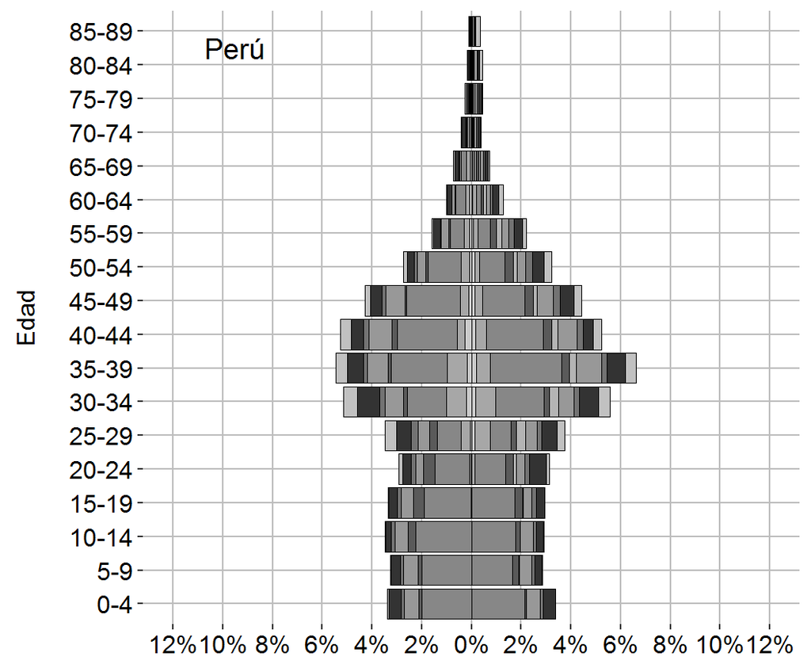

```r
library(ggplot2)
CAP6_GRAFIC4 <- read.csv("C:/Users/jgaleano/Desktop/ICARIA/CAP_6_GRAFIC4_PERU.csv", stringsAsFactors=FALSE)

CAP6_GRAFIC4$EDAD <- factor(CAP6_GRAFIC4$EDAD,
                   levels = c("0-4","5-9","10-14","15-19","20-24","25-29","30-34","35-39","40-44","45-49",
                              "50-54","55-59","60-64","65-69","70-74","75-79","80-84","85-89"))


A<-ggplot(CAP6_GRAFIC4, aes(x=factor(EDAD), y=PROP, fill=HOGARES))+
  geom_bar(data = CAP6_GRAFIC4[(CAP6_GRAFIC4$SEX2=="Pareja con hijos Mujeres"|
                                         CAP6_GRAFIC4$SEX2=="Pareja con hijos y otros Mujeres"|
                                         CAP6_GRAFIC4$SEX2=="Personas no vinculadas por pareja o filiación Mujeres"|
                                         CAP6_GRAFIC4$SEX2=="Dos o más nucleos de pareja o filiación Mujeres"|
                                         CAP6_GRAFIC4$SEX2=="Monoparentales y otros Mujeres"|
                                         CAP6_GRAFIC4$SEX2=="Pareja sin hijos Mujeres"|
                                         CAP6_GRAFIC4$SEX2=="Pareja sin hijos y otros Mujeres"|
                                         CAP6_GRAFIC4$SEX2=="Unipersonales Mujeres"|
                                         CAP6_GRAFIC4$SEX2=="Monoparentales Mujeres"),],
           colour = I("Black"),stat="identity", size=.3, colour="black",
           aes(x = EDAD, y = PROP,fill = HOGARES), alpha = 1)+
  geom_bar(data = CAP6_GRAFIC4[(CAP6_GRAFIC4$SEX2=="Pareja con hijos Hombres"|
                                           CAP6_GRAFIC4$SEX2=="Pareja con hijos y otros Hombres"|
                                           CAP6_GRAFIC4$SEX2=="Personas no vinculadas por pareja o filiación Hombres"|
                                           CAP6_GRAFIC4$SEX2=="Dos o más nucleos de pareja o filiación Hombres"|
                                           CAP6_GRAFIC4$SEX2=="Monoparentales y otros Hombres"|
                                           CAP6_GRAFIC4$SEX2=="Pareja sin hijos Hombres"|
                                           CAP6_GRAFIC4$SEX2=="Pareja sin hijos y otros Hombre"|
                                           CAP6_GRAFIC4$SEX2=="Unipersonales Hombres"|
                                           CAP6_GRAFIC4$SEX2=="Monoparentales Hombres"),],
           colour = I("Black"),stat="identity", size=.3, colour="black",
           aes(x = EDAD, y = PROP,fill = HOGARES), alpha = 1)+
  coord_flip()+
scale_y_continuous(limits=c(-12,12),breaks = c(-12, -10, -8, -6, -4, -2,0, 2, 4, 6, 8, 10, 12),
                     labels = paste0(as.character(c(seq(12, 0, -2), seq(2, 12, 2))), "%")) +
   scale_fill_grey()+

  annotate("text", x = 17.5, y = -9.5, label = "Perú",size=5)+

 theme(plot.title = element_text(lineheight=5.6, size=10, face="bold"),
              legend.title = element_blank(),
              legend.text = element_text(colour="black", size = 12),
              legend.position="none",
              legend.background = element_rect(fill="#FFFFFF"),
              legend.justification=c(0,1),
              legend.key.size = unit(1, "cm"),
              axis.title.x = element_blank(),
              axis.text.x  = element_text(angle = 0,vjust=0.5, size=12,colour="black"),
              axis.title.y = element_text(colour="black", size=12),
              axis.text.y  = element_text(vjust=0.5, size=12,colour="black"),
              strip.text=element_text(angle = 0,vjust=0.5, size=9,colour="black", face = "bold"),
              panel.background = element_rect(fill = "#FFFFFF"),
              panel.grid = element_line(colour="#000000"),
              panel.grid.major=element_line(colour="#BDBDBD"),
              panel.grid.minor=element_line(colour="white"),
              plot.background = element_rect(fill = "#FFFFFF"))+
  xlab("Edad\n")
A
```

```r
setwd("C:\\Users\\jgaleano\\Desktop\\ICARIA\\GRAFICOS")
#ggsave("CAP6_FIG4_PIRAMIDE_PERU.tiff", scale = 3, width = 5.5, height = 4.1, units = c("cm"), dpi = 300)
```

#### **Figura 6.4: Pirámides por origen del hogar y estructura familiar, 2011 (REINO UNIDO)**

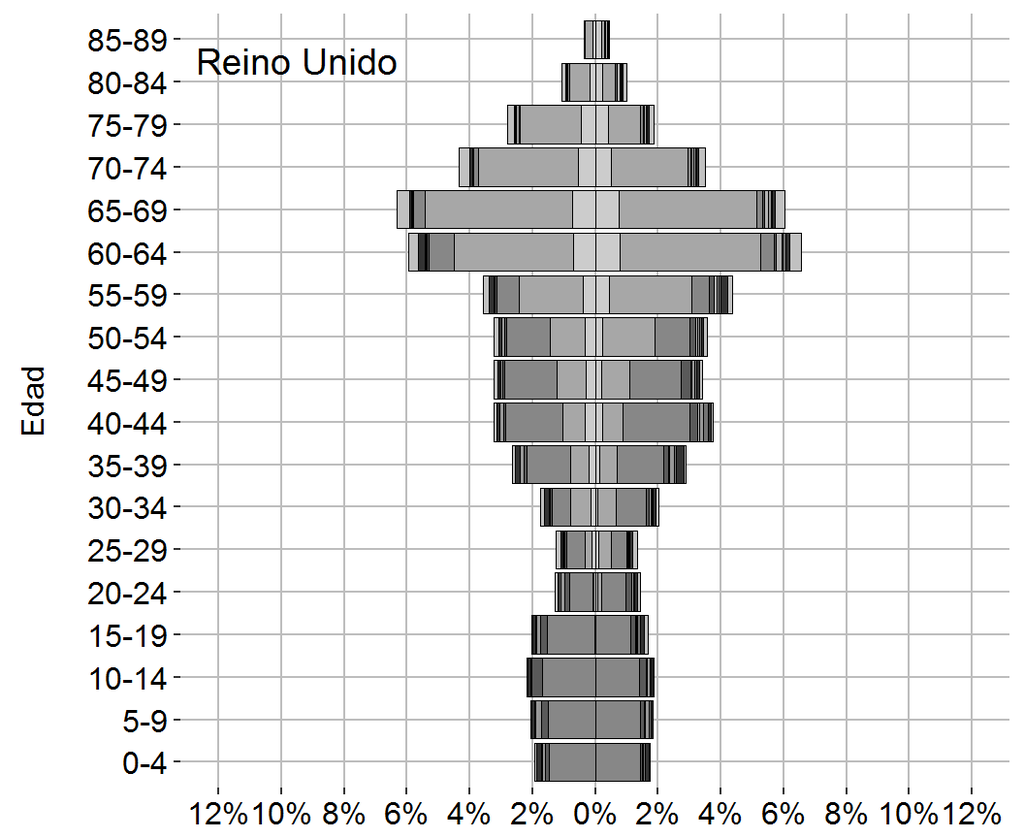

```r
library(ggplot2)
CAP6_GRAFIC4 <- read.csv("C:/Users/jgaleano/Desktop/ICARIA/CAP_6_GRAFIC4_UK.csv", stringsAsFactors=FALSE)

CAP6_GRAFIC4$EDAD <- factor(CAP6_GRAFIC4$EDAD,
                   levels = c("0-4","5-9","10-14","15-19","20-24","25-29","30-34","35-39","40-44","45-49",
                              "50-54","55-59","60-64","65-69","70-74","75-79","80-84","85-89"))


A<-ggplot(CAP6_GRAFIC4, aes(x=factor(EDAD), y=PROP, fill=HOGARES))+
  geom_bar(data = CAP6_GRAFIC4[(CAP6_GRAFIC4$SEX2=="Pareja con hijos Mujeres"|
                                         CAP6_GRAFIC4$SEX2=="Pareja con hijos y otros Mujeres"|
                                         CAP6_GRAFIC4$SEX2=="Personas no vinculadas por pareja o filiación Mujeres"|
                                         CAP6_GRAFIC4$SEX2=="Dos o más nucleos de pareja o filiación Mujeres"|
                                         CAP6_GRAFIC4$SEX2=="Monoparentales y otros Mujeres"|
                                         CAP6_GRAFIC4$SEX2=="Pareja sin hijos Mujeres"|
                                         CAP6_GRAFIC4$SEX2=="Pareja sin hijos y otros Mujeres"|
                                         CAP6_GRAFIC4$SEX2=="Unipersonales Mujeres"|
                                         CAP6_GRAFIC4$SEX2=="Monoparentales Mujeres"),],
           colour = I("Black"),stat="identity", size=.3, colour="black",
           aes(x = EDAD, y = PROP,fill = HOGARES), alpha = 1)+
  geom_bar(data = CAP6_GRAFIC4[(CAP6_GRAFIC4$SEX2=="Pareja con hijos Hombres"|
                                           CAP6_GRAFIC4$SEX2=="Pareja con hijos y otros Hombres"|
                                           CAP6_GRAFIC4$SEX2=="Personas no vinculadas por pareja o filiación Hombres"|
                                           CAP6_GRAFIC4$SEX2=="Dos o más nucleos de pareja o filiación Hombres"|
                                           CAP6_GRAFIC4$SEX2=="Monoparentales y otros Hombres"|
                                           CAP6_GRAFIC4$SEX2=="Pareja sin hijos Hombres"|
                                           CAP6_GRAFIC4$SEX2=="Pareja sin hijos y otros Hombre"|
                                           CAP6_GRAFIC4$SEX2=="Unipersonales Hombres"|
                                           CAP6_GRAFIC4$SEX2=="Monoparentales Hombres"),],
           colour = I("Black"),stat="identity", size=.3, colour="black",
           aes(x = EDAD, y = PROP,fill = HOGARES), alpha = 1)+
  coord_flip()+
scale_y_continuous(limits=c(-12,12),breaks = c(-12, -10, -8, -6, -4, -2,0, 2, 4, 6, 8, 10, 12),
                     labels = paste0(as.character(c(seq(12, 0, -2), seq(2, 12, 2))), "%")) +
   scale_fill_grey()+

  annotate("text", x = 17.5, y = -9.5, label = "Reino Unido",size=5)+

 theme(plot.title = element_text(lineheight=5.6, size=10, face="bold"),
              legend.title = element_blank(),
              legend.text = element_text(colour="black", size = 12),
              legend.position="none",
              legend.background = element_rect(fill="#FFFFFF"),
              legend.justification=c(0,1),
              legend.key.size = unit(1, "cm"),
              axis.title.x = element_blank(),
              axis.text.x  = element_text(angle = 0,vjust=0.5, size=12,colour="black"),
              axis.title.y = element_text(colour="black", size=12),
              axis.text.y  = element_text(vjust=0.5, size=12,colour="black"),
              strip.text=element_text(angle = 0,vjust=0.5, size=9,colour="black", face = "bold"),
              panel.background = element_rect(fill = "#FFFFFF"),
              panel.grid = element_line(colour="#000000"),
              panel.grid.major=element_line(colour="#BDBDBD"),
              panel.grid.minor=element_line(colour="white"),
              plot.background = element_rect(fill = "#FFFFFF"))+
  xlab("Edad\n")
A
```

```r
setwd("C:\\Users\\jgaleano\\Desktop\\ICARIA\\GRAFICOS")
#ggsave("CAP6_FIG4_PIRAMIDE_UK.tiff", scale = 3, width = 5.5, height = 4.1, units = c("cm"), dpi = 300)
```

#### **Figura 6.4: Pirámides por origen del hogar y estructura familiar, 2011 (ARGENTINA)**

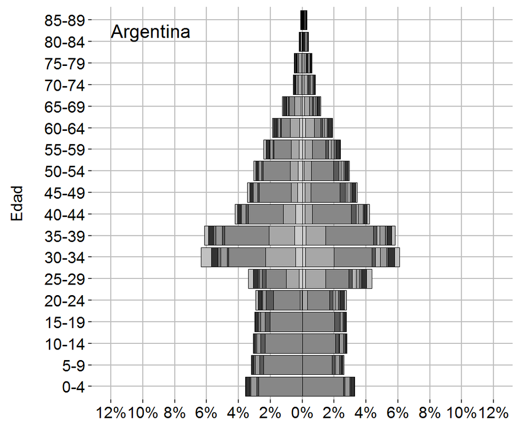

```r
library(ggplot2)
CAP6_GRAFIC4 <- read.csv("C:/Users/jgaleano/Desktop/ICARIA/CAP_6_GRAFIC4_ARGENTINA.csv", stringsAsFactors=FALSE)

CAP6_GRAFIC4$EDAD <- factor(CAP6_GRAFIC4$EDAD,
                   levels = c("0-4","5-9","10-14","15-19","20-24","25-29","30-34","35-39","40-44","45-49",
                              "50-54","55-59","60-64","65-69","70-74","75-79","80-84","85-89"))


A<-ggplot(CAP6_GRAFIC4, aes(x=factor(EDAD), y=PROP, fill=HOGARES))+
  geom_bar(data = CAP6_GRAFIC4[(CAP6_GRAFIC4$SEX2=="Pareja con hijos Mujeres"|
                                         CAP6_GRAFIC4$SEX2=="Pareja con hijos y otros Mujeres"|
                                         CAP6_GRAFIC4$SEX2=="Personas no vinculadas por pareja o filiación Mujeres"|
                                         CAP6_GRAFIC4$SEX2=="Dos o más nucleos de pareja o filiación Mujeres"|
                                         CAP6_GRAFIC4$SEX2=="Monoparentales y otros Mujeres"|
                                         CAP6_GRAFIC4$SEX2=="Pareja sin hijos Mujeres"|
                                         CAP6_GRAFIC4$SEX2=="Pareja sin hijos y otros Mujeres"|
                                         CAP6_GRAFIC4$SEX2=="Unipersonales Mujeres"|
                                         CAP6_GRAFIC4$SEX2=="Monoparentales Mujeres"),],
           colour = I("Black"),stat="identity", size=.3, colour="black",
           aes(x = EDAD, y = PROP,fill = HOGARES), alpha = 1)+
  geom_bar(data = CAP6_GRAFIC4[(CAP6_GRAFIC4$SEX2=="Pareja con hijos Hombres"|
                                           CAP6_GRAFIC4$SEX2=="Pareja con hijos y otros Hombres"|
                                           CAP6_GRAFIC4$SEX2=="Personas no vinculadas por pareja o filiación Hombres"|
                                           CAP6_GRAFIC4$SEX2=="Dos o más nucleos de pareja o filiación Hombres"|
                                           CAP6_GRAFIC4$SEX2=="Monoparentales y otros Hombres"|
                                           CAP6_GRAFIC4$SEX2=="Pareja sin hijos Hombres"|
                                           CAP6_GRAFIC4$SEX2=="Pareja sin hijos y otros Hombre"|
                                           CAP6_GRAFIC4$SEX2=="Unipersonales Hombres"|
                                           CAP6_GRAFIC4$SEX2=="Monoparentales Hombres"),],
           colour = I("Black"),stat="identity", size=.3, colour="black",
           aes(x = EDAD, y = PROP,fill = HOGARES), alpha = 1)+
  coord_flip()+
scale_y_continuous(limits=c(-12,12),breaks = c(-12, -10, -8, -6, -4, -2,0, 2, 4, 6, 8, 10, 12),
                     labels = paste0(as.character(c(seq(12, 0, -2), seq(2, 12, 2))), "%")) +
   scale_fill_grey()+

  annotate("text", x = 17.5, y = -9.5, label = "Argentina",size=5)+

 theme(plot.title = element_text(lineheight=5.6, size=10, face="bold"),
              legend.title = element_blank(),
              legend.text = element_text(colour="black", size = 12),
              legend.position="none",
              legend.background = element_rect(fill="#FFFFFF"),
              legend.justification=c(0,1),
              legend.key.size = unit(1, "cm"),
              axis.title.x = element_blank(),
              axis.text.x  = element_text(angle = 0,vjust=0.5, size=12,colour="black"),
              axis.title.y = element_text(colour="black", size=12),
              axis.text.y  = element_text(vjust=0.5, size=12,colour="black"),
              strip.text=element_text(angle = 0,vjust=0.5, size=9,colour="black", face = "bold"),
              panel.background = element_rect(fill = "#FFFFFF"),
              panel.grid = element_line(colour="#000000"),
              panel.grid.major=element_line(colour="#BDBDBD"),
              panel.grid.minor=element_line(colour="white"),
              plot.background = element_rect(fill = "#FFFFFF"))+
  xlab("Edad\n")
A
```

```r
setwd("C:\\Users\\jgaleano\\Desktop\\ICARIA\\GRAFICOS")
#ggsave("CAP6_FIG4_PIRAMIDE_ARGENTINA.tiff", scale = 3, width = 5.5, height = 4.1, units = c("cm"), dpi = 300)
```

#### **Figura 6.4: Pirámides por origen del hogar y estructura familiar, 2011 (BOLIVIA)**

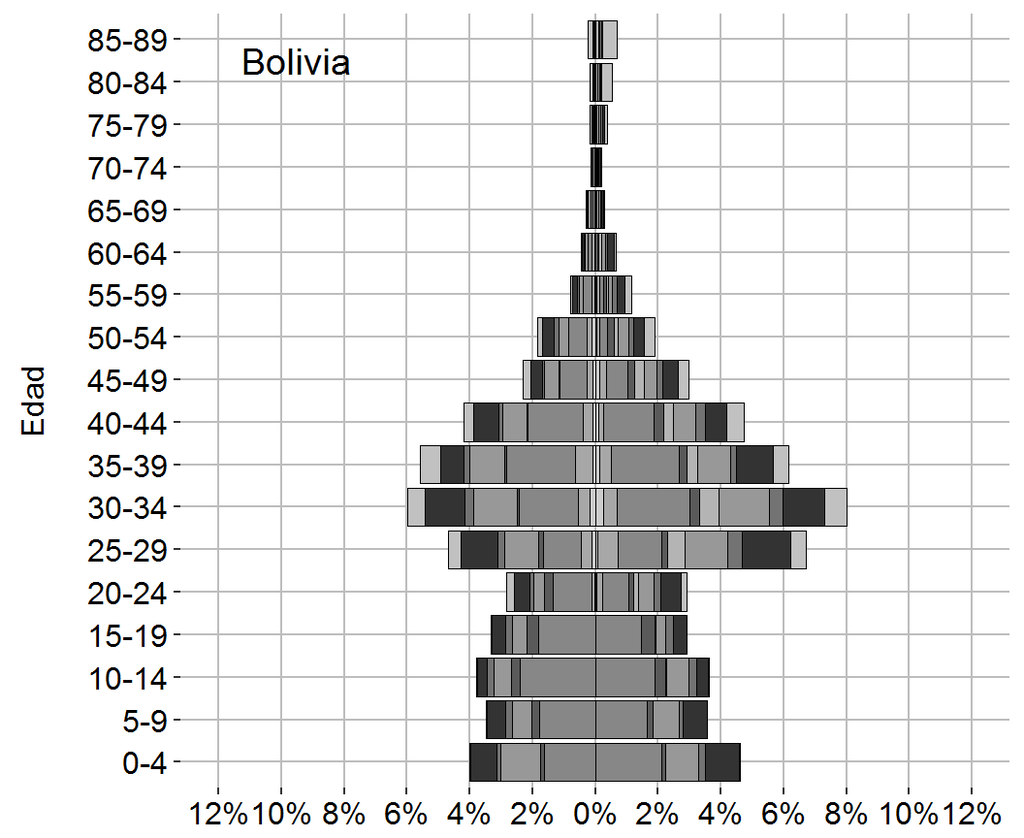

```r
library(ggplot2)
CAP6_GRAFIC4 <- read.csv("C:/Users/jgaleano/Desktop/ICARIA/CAP_6_GRAFIC4_BOLIVIA.csv", stringsAsFactors=FALSE)

CAP6_GRAFIC4$EDAD <- factor(CAP6_GRAFIC4$EDAD,
                   levels = c("0-4","5-9","10-14","15-19","20-24","25-29","30-34","35-39","40-44","45-49",
                              "50-54","55-59","60-64","65-69","70-74","75-79","80-84","85-89"))


A<-ggplot(CAP6_GRAFIC4, aes(x=factor(EDAD), y=PROP, fill=HOGARES))+
  geom_bar(data = CAP6_GRAFIC4[(CAP6_GRAFIC4$SEX2=="Pareja con hijos Mujeres"|
                                         CAP6_GRAFIC4$SEX2=="Pareja con hijos y otros Mujeres"|
                                         CAP6_GRAFIC4$SEX2=="Personas no vinculadas por pareja o filiación Mujeres"|
                                         CAP6_GRAFIC4$SEX2=="Dos o más nucleos de pareja o filiación Mujeres"|
                                         CAP6_GRAFIC4$SEX2=="Monoparentales y otros Mujeres"|
                                         CAP6_GRAFIC4$SEX2=="Pareja sin hijos Mujeres"|
                                         CAP6_GRAFIC4$SEX2=="Pareja sin hijos y otros Mujeres"|
                                         CAP6_GRAFIC4$SEX2=="Unipersonales Mujeres"|
                                         CAP6_GRAFIC4$SEX2=="Monoparentales Mujeres"),],
           colour = I("Black"),stat="identity", size=.3, colour="black",
           aes(x = EDAD, y = PROP,fill = HOGARES), alpha = 1)+
  geom_bar(data = CAP6_GRAFIC4[(CAP6_GRAFIC4$SEX2=="Pareja con hijos Hombres"|
                                           CAP6_GRAFIC4$SEX2=="Pareja con hijos y otros Hombres"|
                                           CAP6_GRAFIC4$SEX2=="Personas no vinculadas por pareja o filiación Hombres"|
                                           CAP6_GRAFIC4$SEX2=="Dos o más nucleos de pareja o filiación Hombres"|
                                           CAP6_GRAFIC4$SEX2=="Monoparentales y otros Hombres"|
                                           CAP6_GRAFIC4$SEX2=="Pareja sin hijos Hombres"|
                                           CAP6_GRAFIC4$SEX2=="Pareja sin hijos y otros Hombre"|
                                           CAP6_GRAFIC4$SEX2=="Unipersonales Hombres"|
                                           CAP6_GRAFIC4$SEX2=="Monoparentales Hombres"),],
           colour = I("Black"),stat="identity", size=.3, colour="black",
           aes(x = EDAD, y = PROP,fill = HOGARES), alpha = 1)+
  coord_flip()+
scale_y_continuous(limits=c(-12,12),breaks = c(-12, -10, -8, -6, -4, -2,0, 2, 4, 6, 8, 10, 12),
                     labels = paste0(as.character(c(seq(12, 0, -2), seq(2, 12, 2))), "%")) +
   scale_fill_grey()+

  annotate("text", x = 17.5, y = -9.5, label = "Bolivia",size=5)+

 theme(plot.title = element_text(lineheight=5.6, size=10, face="bold"),
              legend.title = element_blank(),
              legend.text = element_text(colour="black", size = 12),
              legend.position="none",
              legend.background = element_rect(fill="#FFFFFF"),
              legend.justification=c(0,1),
              legend.key.size = unit(1, "cm"),
              axis.title.x = element_blank(),
              axis.text.x  = element_text(angle = 0,vjust=0.5, size=12,colour="black"),
              axis.title.y = element_text(colour="black", size=12),
              axis.text.y  = element_text(vjust=0.5, size=12,colour="black"),
              strip.text=element_text(angle = 0,vjust=0.5, size=9,colour="black", face = "bold"),
              panel.background = element_rect(fill = "#FFFFFF"),
              panel.grid = element_line(colour="#000000"),
              panel.grid.major=element_line(colour="#BDBDBD"),
              panel.grid.minor=element_line(colour="white"),
              plot.background = element_rect(fill = "#FFFFFF"))+
  xlab("Edad\n")
A
```

```r
setwd("C:\\Users\\jgaleano\\Desktop\\ICARIA\\GRAFICOS")
#ggsave("CAP6_FIG4_PIRAMIDE_BOLIVIA.tiff", scale = 3, width = 5.5, height = 4.1, units = c("cm"), dpi = 300)
```

#### **Figura 6.4: Pirámides por origen del hogar y estructura familiar, 2011 (FILIPINAS)**

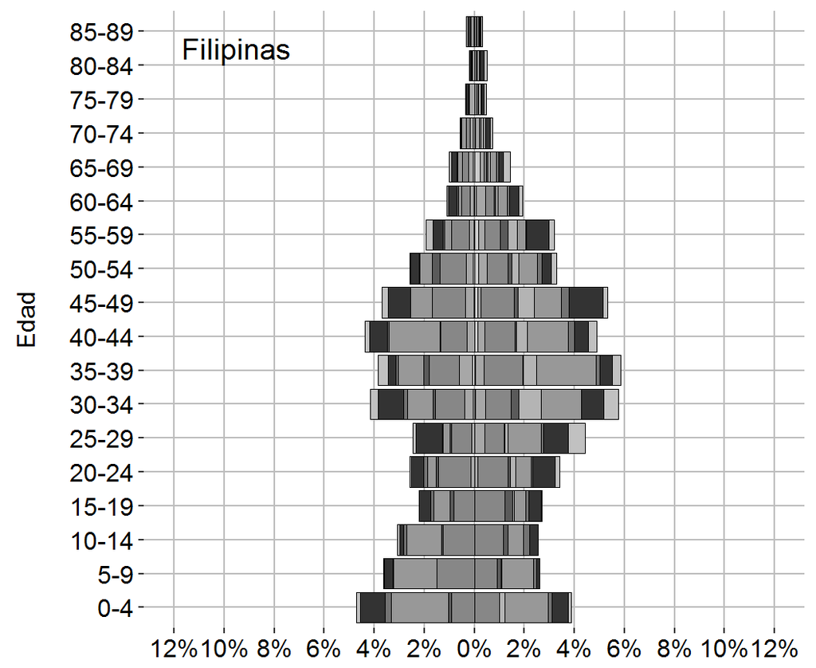

```r
library(ggplot2)
CAP6_GRAFIC4 <- read.csv("C:/Users/jgaleano/Desktop/ICARIA/CAP_6_GRAFIC4_FILIPINAS.csv", stringsAsFactors=FALSE)

CAP6_GRAFIC4$EDAD <- factor(CAP6_GRAFIC4$EDAD,
                   levels = c("0-4","5-9","10-14","15-19","20-24","25-29","30-34","35-39","40-44","45-49",
                              "50-54","55-59","60-64","65-69","70-74","75-79","80-84","85-89"))


A<-ggplot(CAP6_GRAFIC4, aes(x=factor(EDAD), y=PROP, fill=HOGARES))+
  geom_bar(data = CAP6_GRAFIC4[(CAP6_GRAFIC4$SEX2=="Pareja con hijos Mujeres"|
                                         CAP6_GRAFIC4$SEX2=="Pareja con hijos y otros Mujeres"|
                                         CAP6_GRAFIC4$SEX2=="Personas no vinculadas por pareja o filiación Mujeres"|
                                         CAP6_GRAFIC4$SEX2=="Dos o más nucleos de pareja o filiación Mujeres"|
                                         CAP6_GRAFIC4$SEX2=="Monoparentales y otros Mujeres"|
                                         CAP6_GRAFIC4$SEX2=="Pareja sin hijos Mujeres"|
                                         CAP6_GRAFIC4$SEX2=="Pareja sin hijos y otros Mujeres"|
                                         CAP6_GRAFIC4$SEX2=="Unipersonales Mujeres"|
                                         CAP6_GRAFIC4$SEX2=="Monoparentales Mujeres"),],
           colour = I("Black"),stat="identity", size=.3, colour="black",
           aes(x = EDAD, y = PROP,fill = HOGARES), alpha = 1)+
  geom_bar(data = CAP6_GRAFIC4[(CAP6_GRAFIC4$SEX2=="Pareja con hijos Hombres"|
                                           CAP6_GRAFIC4$SEX2=="Pareja con hijos y otros Hombres"|
                                           CAP6_GRAFIC4$SEX2=="Personas no vinculadas por pareja o filiación Hombres"|
                                           CAP6_GRAFIC4$SEX2=="Dos o más nucleos de pareja o filiación Hombres"|
                                           CAP6_GRAFIC4$SEX2=="Monoparentales y otros Hombres"|
                                           CAP6_GRAFIC4$SEX2=="Pareja sin hijos Hombres"|
                                           CAP6_GRAFIC4$SEX2=="Pareja sin hijos y otros Hombre"|
                                           CAP6_GRAFIC4$SEX2=="Unipersonales Hombres"|
                                           CAP6_GRAFIC4$SEX2=="Monoparentales Hombres"),],
           colour = I("Black"),stat="identity", size=.3, colour="black",
           aes(x = EDAD, y = PROP,fill = HOGARES), alpha = 1)+
  coord_flip()+
scale_y_continuous(limits=c(-12,12),breaks = c(-12, -10, -8, -6, -4, -2,0, 2, 4, 6, 8, 10, 12),
                     labels = paste0(as.character(c(seq(12, 0, -2), seq(2, 12, 2))), "%")) +
   scale_fill_grey()+

  annotate("text", x = 17.5, y = -9.5, label = "Filipinas",size=5)+

 theme(plot.title = element_text(lineheight=5.6, size=10, face="bold"),
              legend.title = element_blank(),
              legend.text = element_text(colour="black", size = 12),
              legend.position="none",
              legend.background = element_rect(fill="#FFFFFF"),
              legend.justification=c(0,1),
              legend.key.size = unit(1, "cm"),
              axis.title.x = element_blank(),
              axis.text.x  = element_text(angle = 0,vjust=0.5, size=12,colour="black"),
              axis.title.y = element_text(colour="black", size=12),
              axis.text.y  = element_text(vjust=0.5, size=12,colour="black"),
              strip.text=element_text(angle = 0,vjust=0.5, size=9,colour="black", face = "bold"),
              panel.background = element_rect(fill = "#FFFFFF"),
              panel.grid = element_line(colour="#000000"),
              panel.grid.major=element_line(colour="#BDBDBD"),
              panel.grid.minor=element_line(colour="white"),
              plot.background = element_rect(fill = "#FFFFFF"))+
  xlab("Edad\n")
A
```

```r
setwd("C:\\Users\\jgaleano\\Desktop\\ICARIA\\GRAFICOS")
#ggsave("CAP6_FIG4_PIRAMIDE_FILIPINAS.tiff", scale = 3, width = 5.5, height = 4.1, units = c("cm"), dpi = 300)
```

#### **Figura 6.4: Pirámides por origen del hogar y estructura familiar, 2011 (CHINA)**

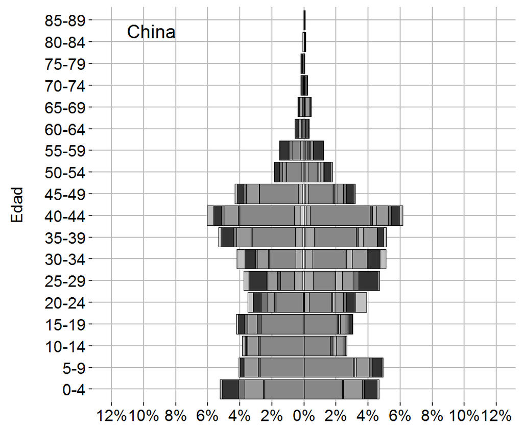

```r
library(ggplot2)
CAP6_GRAFIC4 <- read.csv("C:/Users/jgaleano/Desktop/ICARIA/CAP_6_GRAFIC4_CHINA.csv", stringsAsFactors=FALSE)

CAP6_GRAFIC4$EDAD <- factor(CAP6_GRAFIC4$EDAD,
                   levels = c("0-4","5-9","10-14","15-19","20-24","25-29","30-34","35-39","40-44","45-49",
                              "50-54","55-59","60-64","65-69","70-74","75-79","80-84","85-89"))


A<-ggplot(CAP6_GRAFIC4, aes(x=factor(EDAD), y=PROP, fill=HOGARES))+
  geom_bar(data = CAP6_GRAFIC4[(CAP6_GRAFIC4$SEX2=="Pareja con hijos Mujeres"|
                                         CAP6_GRAFIC4$SEX2=="Pareja con hijos y otros Mujeres"|
                                         CAP6_GRAFIC4$SEX2=="Personas no vinculadas por pareja o filiación Mujeres"|
                                         CAP6_GRAFIC4$SEX2=="Dos o más nucleos de pareja o filiación Mujeres"|
                                         CAP6_GRAFIC4$SEX2=="Monoparentales y otros Mujeres"|
                                         CAP6_GRAFIC4$SEX2=="Pareja sin hijos Mujeres"|
                                         CAP6_GRAFIC4$SEX2=="Pareja sin hijos y otros Mujeres"|
                                         CAP6_GRAFIC4$SEX2=="Unipersonales Mujeres"|
                                         CAP6_GRAFIC4$SEX2=="Monoparentales Mujeres"),],
           colour = I("Black"),stat="identity", size=.3, colour="black",
           aes(x = EDAD, y = PROP,fill = HOGARES), alpha = 1)+
  geom_bar(data = CAP6_GRAFIC4[(CAP6_GRAFIC4$SEX2=="Pareja con hijos Hombres"|
                                           CAP6_GRAFIC4$SEX2=="Pareja con hijos y otros Hombres"|
                                           CAP6_GRAFIC4$SEX2=="Personas no vinculadas por pareja o filiación Hombres"|
                                           CAP6_GRAFIC4$SEX2=="Dos o más nucleos de pareja o filiación Hombres"|
                                           CAP6_GRAFIC4$SEX2=="Monoparentales y otros Hombres"|
                                           CAP6_GRAFIC4$SEX2=="Pareja sin hijos Hombres"|
                                           CAP6_GRAFIC4$SEX2=="Pareja sin hijos y otros Hombre"|
                                           CAP6_GRAFIC4$SEX2=="Unipersonales Hombres"|
                                           CAP6_GRAFIC4$SEX2=="Monoparentales Hombres"),],
           colour = I("Black"),stat="identity", size=.3, colour="black",
           aes(x = EDAD, y = PROP,fill = HOGARES), alpha = 1)+
  coord_flip()+
scale_y_continuous(limits=c(-12,12),breaks = c(-12, -10, -8, -6, -4, -2,0, 2, 4, 6, 8, 10, 12),
                     labels = paste0(as.character(c(seq(12, 0, -2), seq(2, 12, 2))), "%")) +
   scale_fill_grey()+

  annotate("text", x = 17.5, y = -9.5, label = "China",size=5)+

 theme(plot.title = element_text(lineheight=5.6, size=10, face="bold"),
              legend.title = element_blank(),
              legend.text = element_text(colour="black", size = 12),
              legend.position="none",
              legend.background = element_rect(fill="#FFFFFF"),
              legend.justification=c(0,1),
              legend.key.size = unit(1, "cm"),
              axis.title.x = element_blank(),
              axis.text.x  = element_text(angle = 0,vjust=0.5, size=12,colour="black"),
              axis.title.y = element_text(colour="black", size=12),
              axis.text.y  = element_text(vjust=0.5, size=12,colour="black"),
              strip.text=element_text(angle = 0,vjust=0.5, size=9,colour="black", face = "bold"),
              panel.background = element_rect(fill = "#FFFFFF"),
              panel.grid = element_line(colour="#000000"),
              panel.grid.major=element_line(colour="#BDBDBD"),
              panel.grid.minor=element_line(colour="white"),
              plot.background = element_rect(fill = "#FFFFFF"))+
  xlab("Edad\n")
A
```

```r
setwd("C:\\Users\\jgaleano\\Desktop\\ICARIA\\GRAFICOS")
#ggsave("CAP6_FIG4_PIRAMIDE_CHINA.tiff", scale = 3, width = 5.5, height = 4.1, units = c("cm"), dpi = 300)
```

#### **Figura 6.4: Pirámides por origen del hogar y estructura familiar, 2011 (RUSIA)**

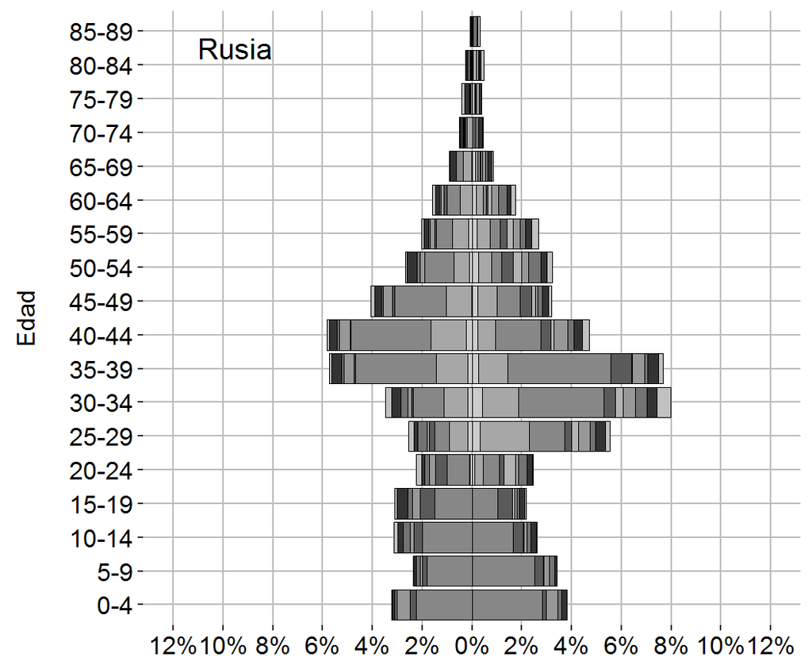

```r
library(ggplot2)
CAP6_GRAFIC4 <- read.csv("C:/Users/jgaleano/Desktop/ICARIA/CAP_6_GRAFIC4_RUSIA.csv", stringsAsFactors=FALSE)

CAP6_GRAFIC4$EDAD <- factor(CAP6_GRAFIC4$EDAD,
                   levels = c("0-4","5-9","10-14","15-19","20-24","25-29","30-34","35-39","40-44","45-49",
                              "50-54","55-59","60-64","65-69","70-74","75-79","80-84","85-89"))


A<-ggplot(CAP6_GRAFIC4, aes(x=factor(EDAD), y=PROP, fill=HOGARES))+
  geom_bar(data = CAP6_GRAFIC4[(CAP6_GRAFIC4$SEX2=="Pareja con hijos Mujeres"|
                                         CAP6_GRAFIC4$SEX2=="Pareja con hijos y otros Mujeres"|
                                         CAP6_GRAFIC4$SEX2=="Personas no vinculadas por pareja o filiación Mujeres"|
                                         CAP6_GRAFIC4$SEX2=="Dos o más nucleos de pareja o filiación Mujeres"|
                                         CAP6_GRAFIC4$SEX2=="Monoparentales y otros Mujeres"|
                                         CAP6_GRAFIC4$SEX2=="Pareja sin hijos Mujeres"|
                                         CAP6_GRAFIC4$SEX2=="Pareja sin hijos y otros Mujeres"|
                                         CAP6_GRAFIC4$SEX2=="Unipersonales Mujeres"|
                                         CAP6_GRAFIC4$SEX2=="Monoparentales Mujeres"),],
           colour = I("Black"),stat="identity", size=.3, colour="black",
           aes(x = EDAD, y = PROP,fill = HOGARES), alpha = 1)+
  geom_bar(data = CAP6_GRAFIC4[(CAP6_GRAFIC4$SEX2=="Pareja con hijos Hombres"|
                                           CAP6_GRAFIC4$SEX2=="Pareja con hijos y otros Hombres"|
                                           CAP6_GRAFIC4$SEX2=="Personas no vinculadas por pareja o filiación Hombres"|
                                           CAP6_GRAFIC4$SEX2=="Dos o más nucleos de pareja o filiación Hombres"|
                                           CAP6_GRAFIC4$SEX2=="Monoparentales y otros Hombres"|
                                           CAP6_GRAFIC4$SEX2=="Pareja sin hijos Hombres"|
                                           CAP6_GRAFIC4$SEX2=="Pareja sin hijos y otros Hombre"|
                                           CAP6_GRAFIC4$SEX2=="Unipersonales Hombres"|
                                           CAP6_GRAFIC4$SEX2=="Monoparentales Hombres"),],
           colour = I("Black"),stat="identity", size=.3, colour="black",
           aes(x = EDAD, y = PROP,fill = HOGARES), alpha = 1)+
  coord_flip()+
scale_y_continuous(limits=c(-12,12),breaks = c(-12, -10, -8, -6, -4, -2,0, 2, 4, 6, 8, 10, 12),
                     labels = paste0(as.character(c(seq(12, 0, -2), seq(2, 12, 2))), "%")) +
   scale_fill_grey()+

  annotate("text", x = 17.5, y = -9.5, label = "Rusia",size=5)+

 theme(plot.title = element_text(lineheight=5.6, size=10, face="bold"),
              legend.title = element_blank(),
              legend.text = element_text(colour="black", size = 12),
              legend.position="none",
              legend.background = element_rect(fill="#FFFFFF"),
              legend.justification=c(0,1),
              legend.key.size = unit(1, "cm"),
              axis.title.x = element_blank(),
              axis.text.x  = element_text(angle = 0,vjust=0.5, size=12,colour="black"),
              axis.title.y = element_text(colour="black", size=12),
              axis.text.y  = element_text(vjust=0.5, size=12,colour="black"),
              strip.text=element_text(angle = 0,vjust=0.5, size=9,colour="black", face = "bold"),
              panel.background = element_rect(fill = "#FFFFFF"),
              panel.grid = element_line(colour="#000000"),
              panel.grid.major=element_line(colour="#BDBDBD"),
              panel.grid.minor=element_line(colour="white"),
              plot.background = element_rect(fill = "#FFFFFF"))+
  xlab("Edad\n")
A
```

```r
setwd("C:\\Users\\jgaleano\\Desktop\\ICARIA\\GRAFICOS")
#ggsave("CAP6_FIG4_PIRAMIDE_RUSIA.tiff", scale = 3, width = 5.5, height = 4.1, units = c("cm"), dpi = 300)
```

#### **Figura 6.4: Pirámides por origen del hogar y estructura familiar, 2011 (SENEGAL)**

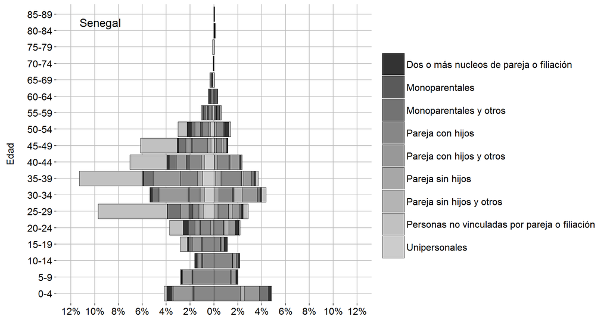

```r
library(ggplot2)
CAP6_GRAFIC4 <- read.csv("C:/Users/jgaleano/Desktop/ICARIA/CAP_6_GRAFIC4_SENEGAL.csv", stringsAsFactors=FALSE)

CAP6_GRAFIC4$EDAD <- factor(CAP6_GRAFIC4$EDAD,
                   levels = c("0-4","5-9","10-14","15-19","20-24","25-29","30-34","35-39","40-44","45-49",
                              "50-54","55-59","60-64","65-69","70-74","75-79","80-84","85-89"))


A<-ggplot(CAP6_GRAFIC4, aes(x=factor(EDAD), y=PROP, fill=HOGARES))+
  geom_bar(data = CAP6_GRAFIC4[(CAP6_GRAFIC4$SEX2=="Pareja con hijos Mujeres"|
                                         CAP6_GRAFIC4$SEX2=="Pareja con hijos y otros Mujeres"|
                                         CAP6_GRAFIC4$SEX2=="Personas no vinculadas por pareja o filiación Mujeres"|
                                         CAP6_GRAFIC4$SEX2=="Dos o más nucleos de pareja o filiación Mujeres"|
                                         CAP6_GRAFIC4$SEX2=="Monoparentales y otros Mujeres"|
                                         CAP6_GRAFIC4$SEX2=="Pareja sin hijos Mujeres"|
                                         CAP6_GRAFIC4$SEX2=="Pareja sin hijos y otros Mujeres"|
                                         CAP6_GRAFIC4$SEX2=="Unipersonales Mujeres"|
                                         CAP6_GRAFIC4$SEX2=="Monoparentales Mujeres"),],
           colour = I("Black"),stat="identity", size=.3, colour="black",
           aes(x = EDAD, y = PROP,fill = HOGARES), alpha = 1)+
  geom_bar(data = CAP6_GRAFIC4[(CAP6_GRAFIC4$SEX2=="Pareja con hijos Hombres"|
                                           CAP6_GRAFIC4$SEX2=="Pareja con hijos y otros Hombres"|
                                           CAP6_GRAFIC4$SEX2=="Personas no vinculadas por pareja o filiación Hombres"|
                                           CAP6_GRAFIC4$SEX2=="Dos o más nucleos de pareja o filiación Hombres"|
                                           CAP6_GRAFIC4$SEX2=="Monoparentales y otros Hombres"|
                                           CAP6_GRAFIC4$SEX2=="Pareja sin hijos Hombres"|
                                           CAP6_GRAFIC4$SEX2=="Pareja sin hijos y otros Hombre"|
                                           CAP6_GRAFIC4$SEX2=="Unipersonales Hombres"|
                                           CAP6_GRAFIC4$SEX2=="Monoparentales Hombres"),],
           colour = I("Black"),stat="identity", size=.3, colour="black",
           aes(x = EDAD, y = PROP,fill = HOGARES), alpha = 1)+
  coord_flip()+
scale_y_continuous(limits=c(-12,12),breaks = c(-12, -10, -8, -6, -4, -2,0, 2, 4, 6, 8, 10, 12),
                     labels = paste0(as.character(c(seq(12, 0, -2), seq(2, 12, 2))), "%")) +
   scale_fill_grey()+

  annotate("text", x = 17.5, y = -9.5, label = "Senegal",size=5)+

 theme(plot.title = element_text(lineheight=5.6, size=10, face="bold"),
              legend.title = element_blank(),
              legend.text = element_text(colour="black", size = 12),
              legend.position = "right",
              legend.background = element_rect(fill="#FFFFFF"),
              #legend.justification=c(0,1),
              legend.key.size = unit(1, "cm"),
              legend.key.size = unit(1, "cm"),
              axis.title.x = element_blank(),
              axis.text.x  = element_text(angle = 0,vjust=0.5, size=12,colour="black"),
              axis.title.y = element_text(colour="black", size=12),
              axis.text.y  = element_text(vjust=0.5, size=12,colour="black"),
              strip.text=element_text(angle = 0,vjust=0.5, size=9,colour="black", face = "bold"),
              panel.background = element_rect(fill = "#FFFFFF"),
              panel.grid = element_line(colour="#000000"),
              panel.grid.major=element_line(colour="#BDBDBD"),
              panel.grid.minor=element_line(colour="white"),
              plot.background = element_rect(fill = "#FFFFFF"))+
  xlab("Edad\n")
A
```

```r
setwd("C:\\Users\\jgaleano\\Desktop\\ICARIA\\GRAFICOS")
#ggsave("CAP6_FIG4_PIRAMIDES_LEYENDA.tiff", scale = 3, width = 13.5, height = 12.1, units = c("cm"), dpi = 300)
```

#### **Figura 6.5: Indicador resumen de la vulnerabilidad del hogar (% hogares vulnerables) por origen**

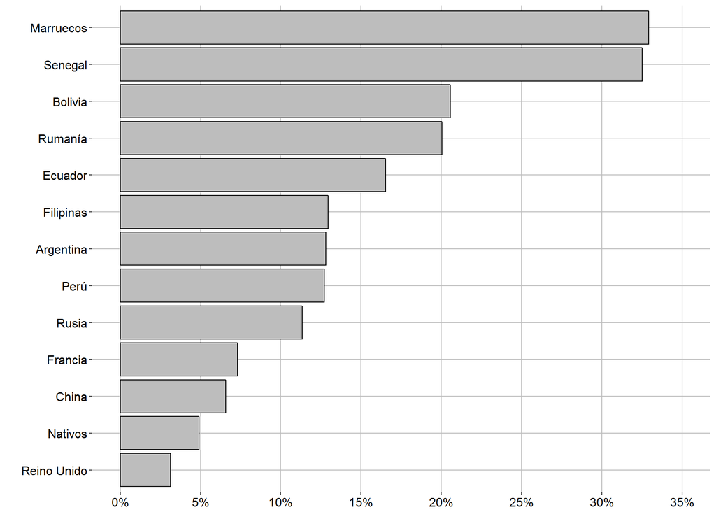

```r
library(ggplot2)
library(scales)
CAP6_GRAFIC5 <- read.csv("C:/Users/jgaleano/Desktop/ICARIA/CAP_6_GRAFIC5.csv", stringsAsFactors=FALSE)

CAP6_GRAFIC5$PAIS <- factor(CAP6_GRAFIC5$PAIS, levels = c("Reino Unido","Nativos","China","Francia","Rusia",
                                                          "Perú", "Argentina","Filipinas","Ecuador","Rumanía",
                                                          "Bolivia","Senegal","Marruecos"))

A<- ggplot(CAP6_GRAFIC5, aes(x = PAIS, y = PROP, fill=PAIS)) + geom_bar(stat = "identity", colour="black")+coord_flip()+
  scale_y_continuous(breaks=c(0,0.05,0.1,0.15,0.2,0.25,0.3,0.35),labels=percent)+
  expand_limits(y=c(0,0.35))+
    scale_fill_manual(values = c("#BDBDBD","#BDBDBD","#BDBDBD","#BDBDBD","#BDBDBD","#BDBDBD","#BDBDBD",
                               "#BDBDBD","#BDBDBD","#BDBDBD","#BDBDBD","#BDBDBD","#BDBDBD"))+
   theme(plot.title = element_text(lineheight=5.6, size=20, face="bold"),
              legend.title = element_blank(),
              legend.text = element_text(colour="black", size = 15),
              legend.position = "none",
              legend.background = element_rect(fill="#FFFFFF"),
              #legend.justification=c(6,2),
              legend.direction = "horizontal",
              legend.key=element_rect(size=10),
              legend.key.size = unit(2.5, "lines"),

              axis.title.x = element_blank(),
              axis.text.x  = element_text(angle = 00,vjust=0.5, size=12,colour="black"),
              axis.title.y = element_text(colour="black", size=12),
              axis.text.y  = element_text(vjust=0.5, size=12,colour="black"),
              strip.text=element_text(angle = 0,vjust=0.5, size=13,colour="black", face = "bold"),
              panel.background = element_rect(fill = "#FFFFFF"),
              panel.grid = element_line(colour="#000000"),
              panel.grid.major=element_line(colour="#BDBDBD"),
              panel.grid.minor=element_line(colour="white"),
              plot.background = element_rect(fill = "#FFFFFF"))+
  ylab("")+ xlab("")
A
```

```r
setwd("C:\\Users\\jgaleano\\Desktop\\ICARIA\\GRAFICOS")
#ggsave("CAP6_FIG5_PASIES HOGARES.tiff", scale = 3, width = 9.8, height = 7, units = c("cm"), dpi = 300)
```

### **Capítulo 7: DIVERSIDAD Y CONCENTRACIÓN TERRITORIAL DE LA POBLACIÓN MARROQUÍ EN ESPAÑA [Autores: Jordi Bayona-i-Carrasco & Hicham Achebak]**

#### **Figura 7.2: Evolución de los espacios de concentración de la población marroquí en España, 2000-2014**

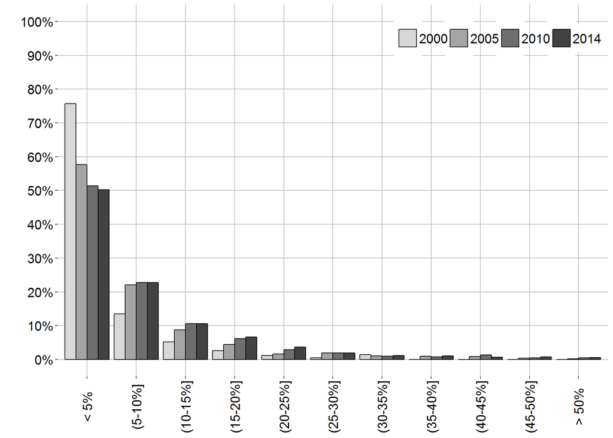

```r
library(ggplot2)
library(scales)
CAP7_GRAFIC2 <- read.csv("C:/Users/jgaleano/Desktop/ICARIA/CAP_7_GRAFIC2.csv", stringsAsFactors=FALSE)

CAP7_GRAFIC2$CAT <- factor(CAP7_GRAFIC2$CAT,  levels = c("< 5%",
                                                        "(5-10%]",
                                                        "(10-15%]",
                                                        "(15-20%]",
                                                        "(20-25%]",
                                                        "(25-30%]",
                                                        "(30-35%]",
                                                        "(35-40%]",
                                                        "(40-45%]",
                                                        "(45-50%]",
                                                        "> 50%"))


A<- ggplot(CAP7_GRAFIC2, aes(x = CAT, y = PROP, fill=factor(YEAR))) + geom_bar(stat = "identity",position = "dodge",colour="black")+#coord_flip()+
  scale_y_continuous(breaks=c(0,0.1,0.2,0.3,0.4,0.5,0.6,0.7,0.8,0.9,1),labels=percent)+
  expand_limits(y=c(0,1))+
    scale_fill_manual(name="",
                     values=c("#D8D8D8", "#A4A4A4", "#6E6E6E", "#424242"),
                     breaks=c("2000","2005","2010","2014"),
                     labels=c("2000","2005","2010","2014"))+
   theme(plot.title = element_text(lineheight=5.6, size=20, face="bold"),
              legend.title = element_blank(),
              legend.text = element_text(colour="black", size = 15),
                 legend.position = c(.80, .91),
              legend.background = element_rect(fill=NA),
              #legend.justification=c(6,2),
              legend.direction = "horizontal",
              legend.key=element_rect(size=10),
              legend.key.size = unit(1.5, "lines"),

              axis.title.x = element_blank(),
              axis.text.x  = element_text(angle = 90,vjust=0.5, size=15,colour="black"),
              axis.title.y = element_text(colour="black", size=15),
              axis.text.y  = element_text(vjust=0.5, size=15,colour="black"),
              strip.text=element_text(angle = 0,vjust=0.5, size=13,colour="black", face = "bold"),
              panel.background = element_rect(fill = "#FFFFFF"),
              panel.grid = element_line(colour="#000000"),
              panel.grid.major=element_line(colour="#BDBDBD"),
              panel.grid.minor=element_line(colour="white"),
              plot.background = element_rect(fill = "#FFFFFF"))+
  ylab("")+ xlab("")
A
```

```r
setwd("C:\\Users\\jgaleano\\Desktop\\ICARIA\\GRAFICOS")
#ggsave("CAP7_FIG2.tiff", scale = 3, width = 9.8, height = 7, units = c("cm"), dpi = 300)
```

#### **Figura 7.3: Composición por nacionalidad de los espacios de concentración de población marroquí, 2000-2014**

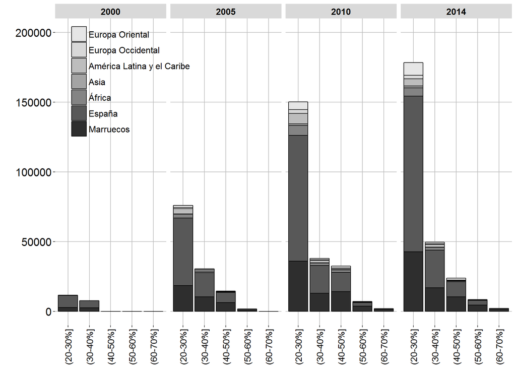

```r
library(ggplot2)
library(scales)
CAP7_GRAFIC3 <- read.csv("C:/Users/jgaleano/Desktop/ICARIA/CAP_7_GRAFIC3.csv", stringsAsFactors=FALSE)

CAP7_GRAFIC3$PAIS <- factor(CAP7_GRAFIC3$PAIS,  levels = c("Marruecos","España","África","Asia","América Latina y el Caribe","Europa Occidental","Europa Oriental"))


A<- ggplot(CAP7_GRAFIC3, aes(x = CAT, y = POP, fill=factor(PAIS))) + geom_bar(stat = "identity",  colour="black")+#coord_flip()+
  expand_limits(y=c(0,200000))+
  facet_grid(~YEAR)+
  scale_fill_manual(name="",
                     values=c("#2E2E2E", "#585858", "#848484", "#A4A4A4", "#BDBDBD", "#D8D8D8", "#E6E6E6"),
                     breaks=rev(c("Marruecos","España","África","Asia","América Latina y el Caribe","Europa Occidental","Europa Oriental")),
                     labels=rev(c("Marruecos","España","África","Asia","América Latina y el Caribe","Europa Occidental","Europa Oriental")))+
   theme(plot.title = element_text(lineheight=5.6, size=20, face="bold"),
              legend.title = element_blank(),
              legend.text = element_text(colour="black", size = 12),
              legend.position = c(.165, .80),
              legend.background = element_rect(fill=NA),
              #legend.justification=c(6,2),
              #legend.direction = "vertical",
              #legend.key=element_rect(size=10),
              legend.key.size = unit(1.5, "lines"),

              axis.title.x = element_blank(),
              axis.text.x  = element_text(angle = 90,vjust=0.5, size=12,colour="black"),
              axis.title.y = element_text(colour="black", size=12),
              axis.text.y  = element_text(vjust=0.5, size=15,colour="black"),
              strip.text=element_text(angle = 0,vjust=0.5, size=12,colour="black", face = "bold"),
              panel.background = element_rect(fill = "#FFFFFF"),
              panel.grid = element_line(colour="#000000"),
              panel.grid.major=element_line(colour="#BDBDBD"),
              panel.grid.minor=element_line(colour="white"),
              plot.background = element_rect(fill = "#FFFFFF"))+
  ylab("")+ xlab("")
A
```

```r
setwd("C:\\Users\\jgaleano\\Desktop\\ICARIA\\GRAFICOS")
#ggsave("CAP7_FIG3.tiff", scale = 3, width = 9.8, height = 7, units = c("cm"), dpi = 300)
```

#### **Figura 7.4: Evolución de la diversidad (índice de diversidad de Simpson) en función de la concentración de la población marroquí, 2000-2014**

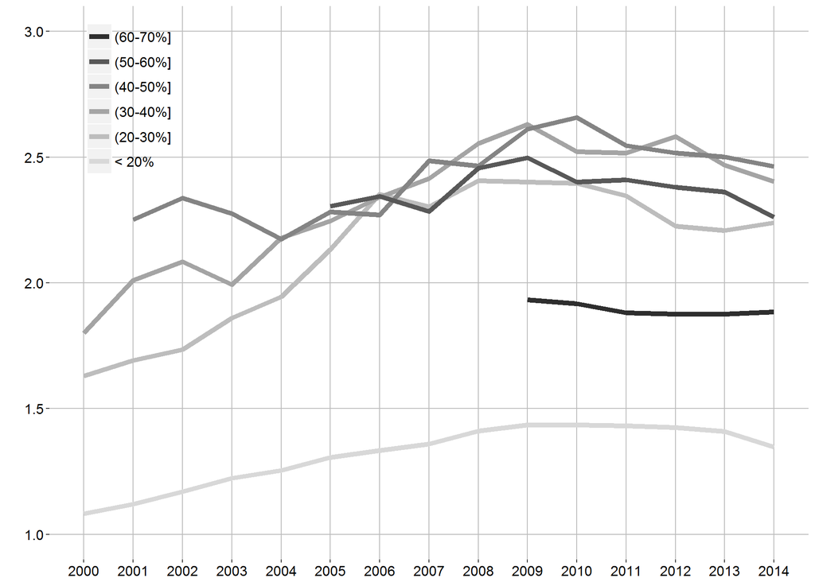

```r
library(ggplot2)
library(scales)
CAP7_GRAFIC4 <- read.csv("C:/Users/jgaleano/Desktop/ICARIA/CAP_7_GRAFIC4.csv", stringsAsFactors=FALSE)

CAP7_GRAFIC4$CAT <- factor(CAP7_GRAFIC4$CAT,  levels = c("< 20%","(20-30%]","(30-40%]", "(40-50%]", "(50-60%]", "(60-70%]"))

A <- ggplot(CAP7_GRAFIC4, aes(x=YEAR, y=PROP, group=CAT))+
  geom_line(aes(colour = CAT), linetype = 1, size=2)+
  scale_y_continuous(breaks=c(1,1.5,2,2.5,3))+
  expand_limits(y=c(1,3))+
   scale_x_continuous(breaks=c(2000,2001,2002,2003,2004,2005,2006,2007,2008,2009,2010,2011,2012,2013,2014))+
  scale_colour_manual(name="",
                     values=rev(c("#2E2E2E", "#585858", "#848484", "#A4A4A4", "#BDBDBD", "#D8D8D8")),
                     breaks=rev(c("< 20%","(20-30%]","(30-40%]", "(40-50%]", "(50-60%]", "(60-70%]")),
                     labels=rev(c("< 20%","(20-30%]","(30-40%]", "(40-50%]", "(50-60%]", "(60-70%]"))) +
   theme(plot.title = element_text(lineheight=5.6, size=20, face="bold"),
              legend.title = element_blank(),
              legend.text = element_text(colour="black", size = 12),
              legend.position = c(.105, .837),
              legend.background = element_rect(fill=NA),
              legend.key.size = unit(1.5, "lines"),
              axis.title.x = element_blank(),
              axis.text.x  = element_text(angle = 0,vjust=0.5, size=12,colour="black"),
              axis.title.y = element_text(colour="black", size=12),
              axis.text.y  = element_text(vjust=0.5, size=12,colour="black"),
              strip.text=element_text(angle = 0,vjust=0.5, size=13,colour="black", face = "bold"),
              panel.background = element_rect(fill = "#FFFFFF"),
              panel.grid = element_line(colour="#000000"),
              panel.grid.major=element_line(colour="#BDBDBD"),
              panel.grid.minor=element_line(colour="white"),
              plot.background = element_rect(fill = "#FFFFFF"))+
  ylab("")+ xlab("")
A
```

```r
setwd("C:\\Users\\jgaleano\\Desktop\\ICARIA\\GRAFICOS")
#ggsave("CAP7_FIG4.tiff", scale = 3, width = 9.8, height = 7, units = c("cm"), dpi = 300)
```